# RBIF112 Course Project

##### icd_10_code

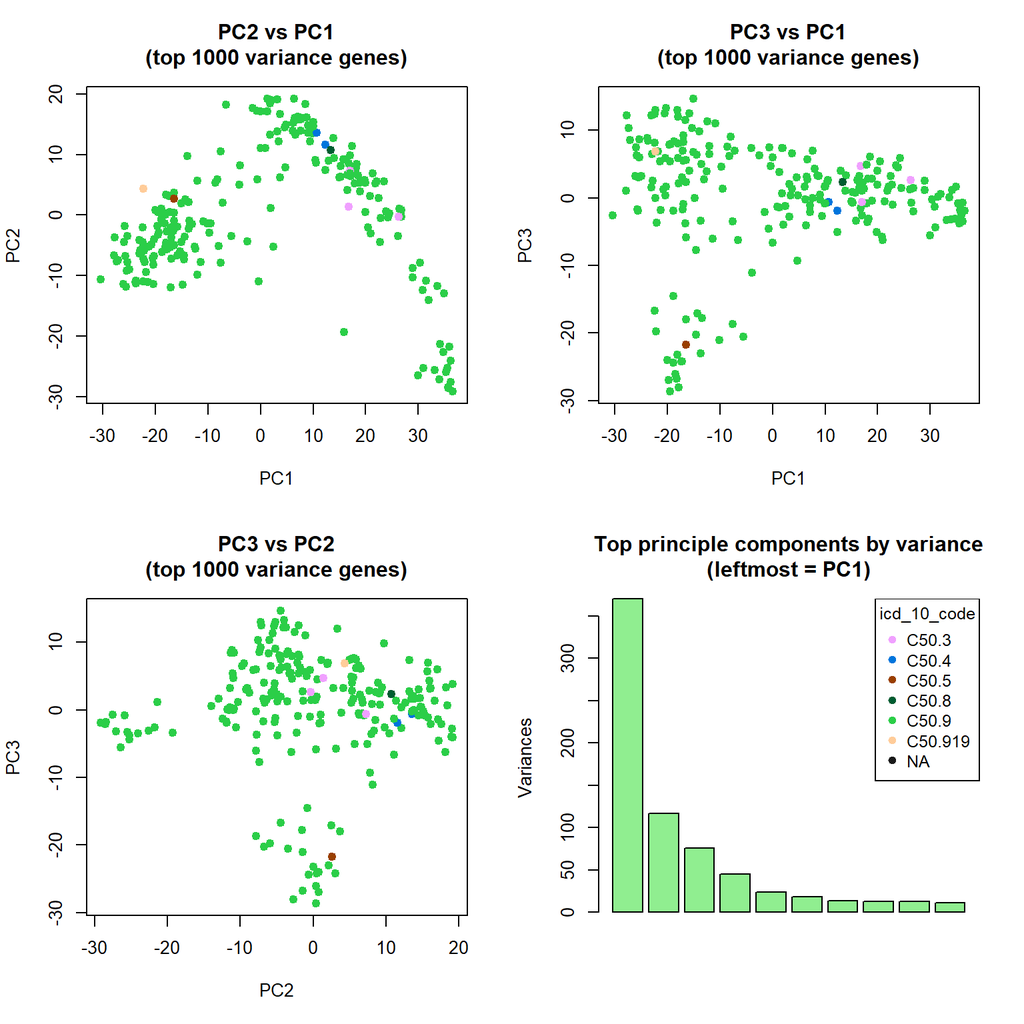

##### site_of_resection_or_biopsy

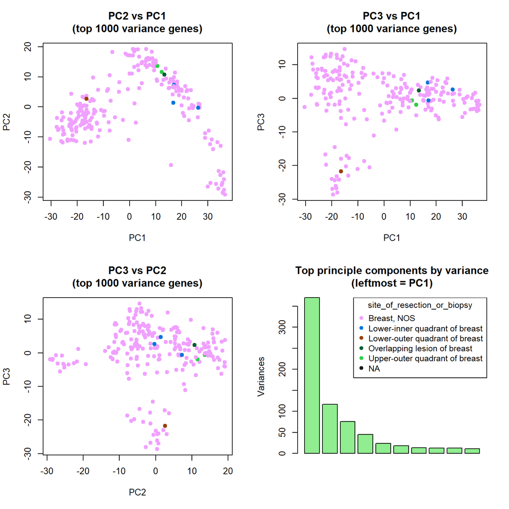

##### race

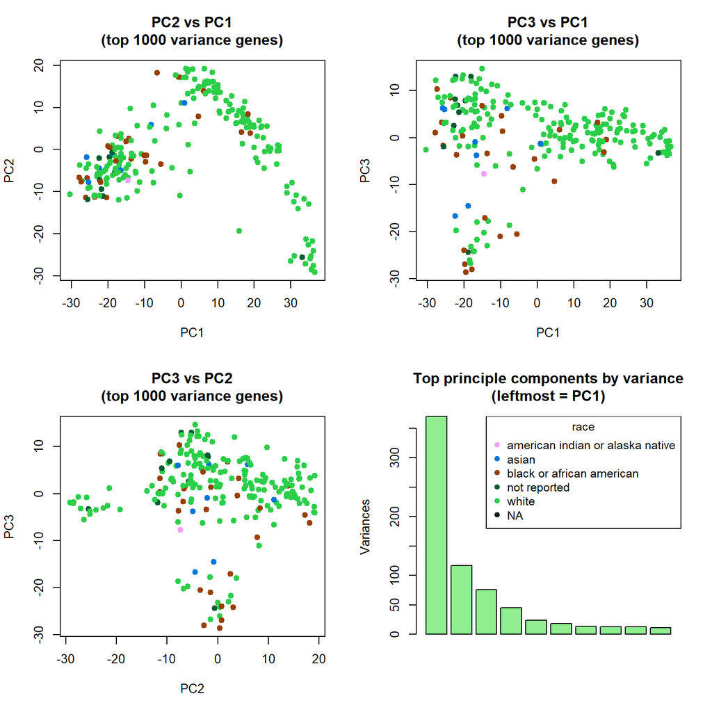

##### gender

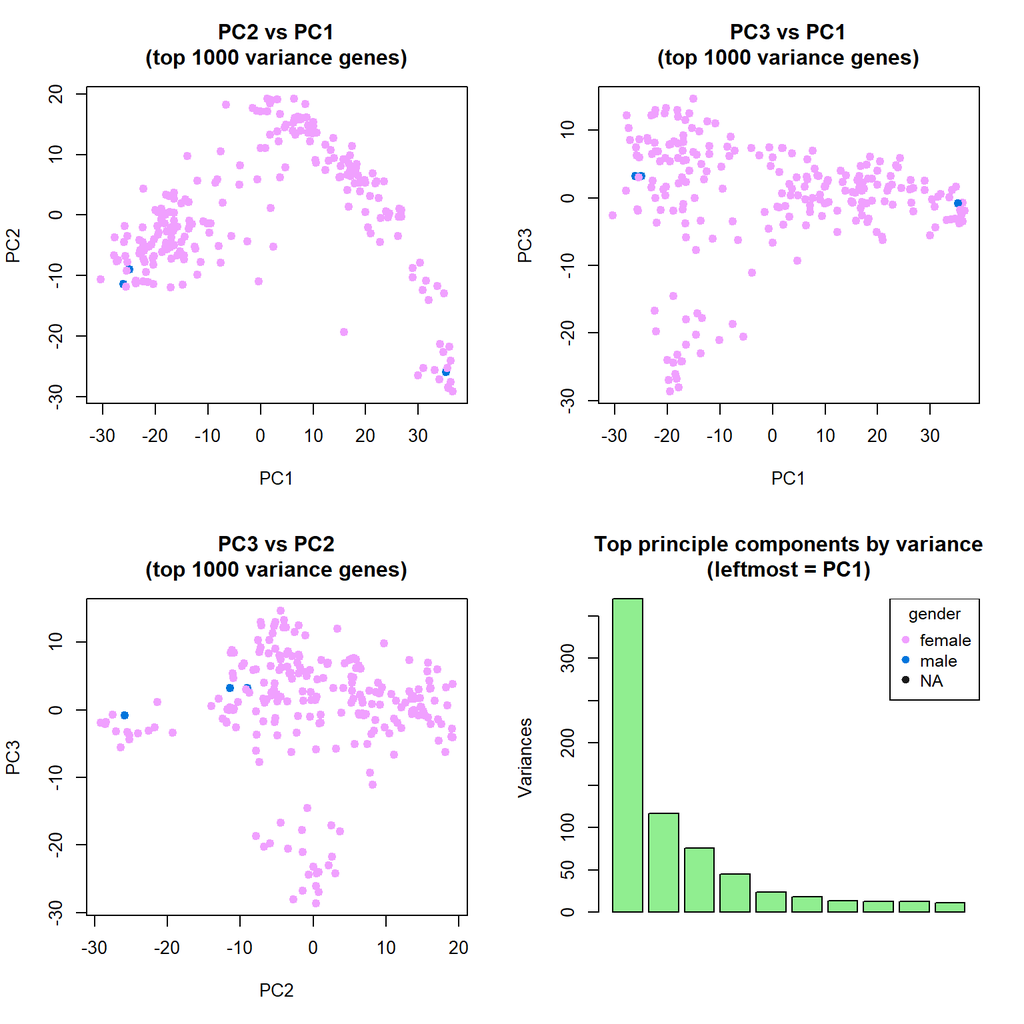

##### ethnicity

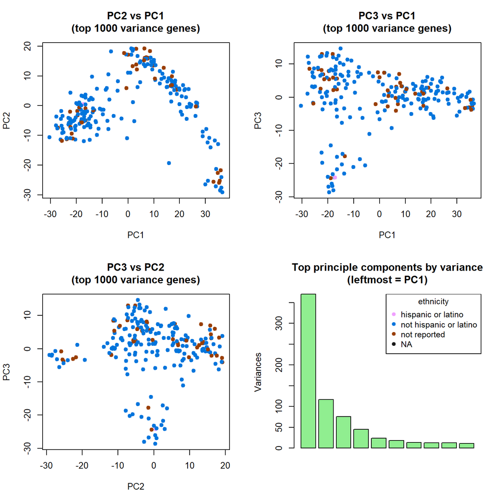

##### vital_status

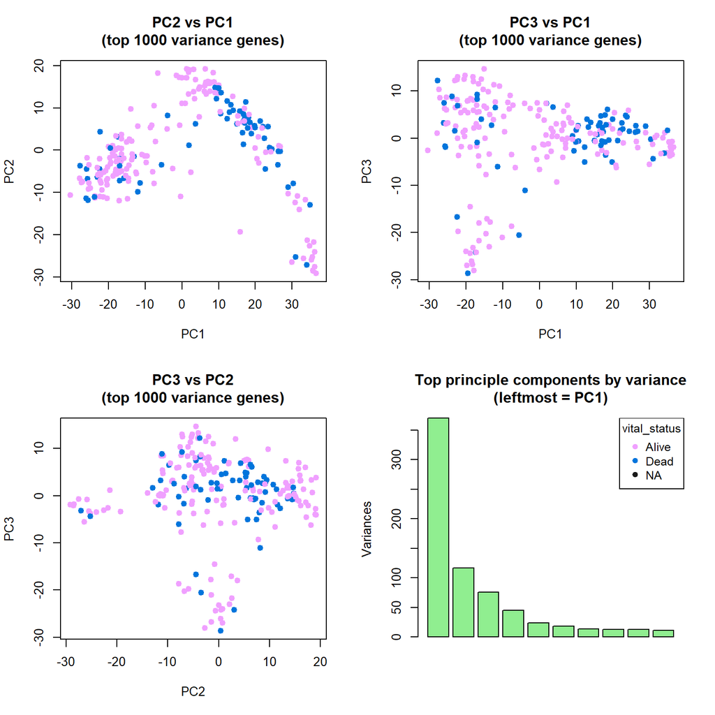

##### paper_pathologic_stage

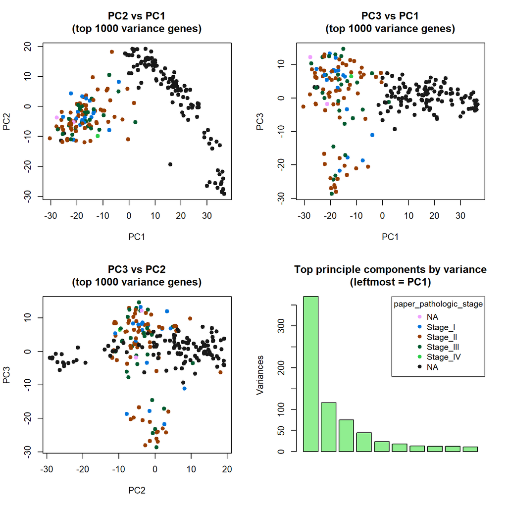

##### paper_BRCA_Pathology

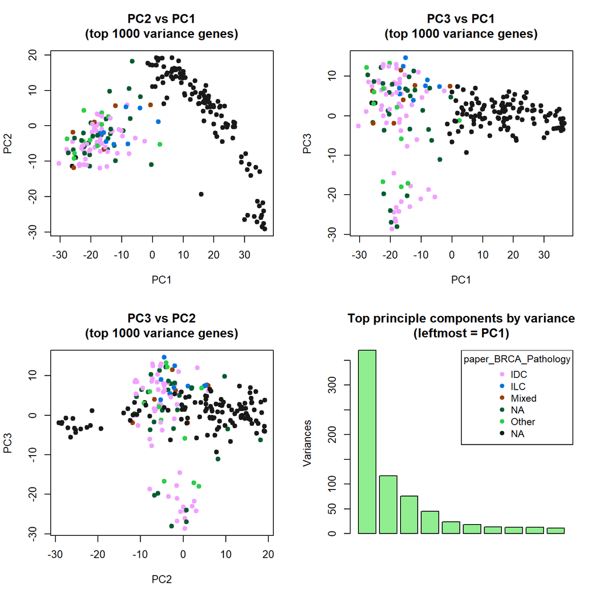

##### paper_BRCA_Subtype_PAM50

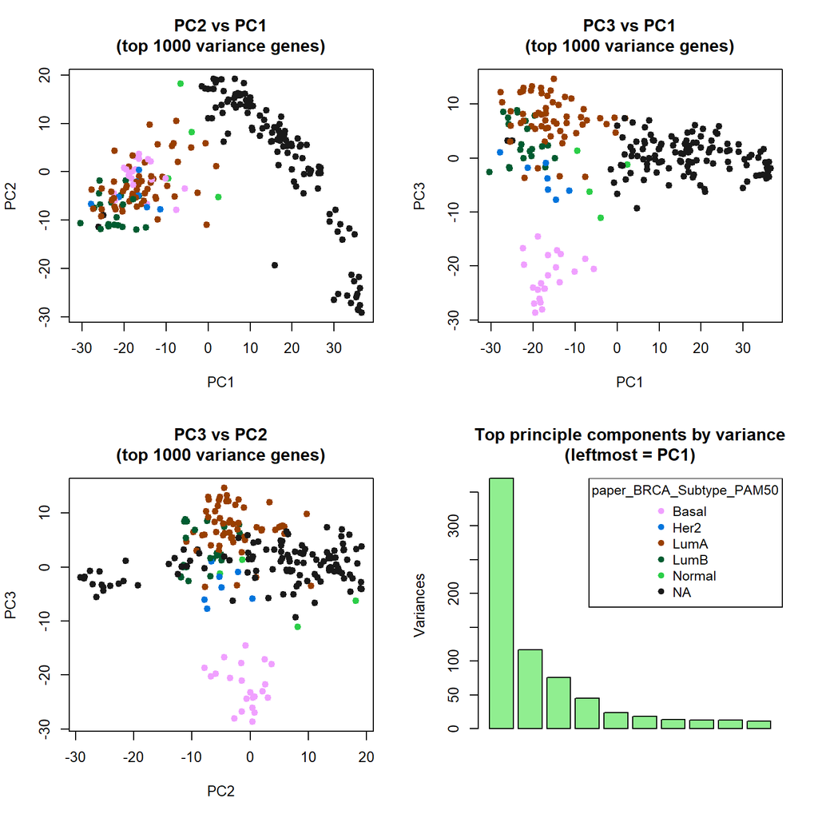

#### PCA takeaways

The major takeaway from the PCA results above is that the dominant pattern in this data set, i.e. the one most apparent among top variance genes, is the tissue/sample type. This is indicated by the very first tab/plot, which clearly shows that a clustering algorithm run on the samples in the PC1-PC2 or PC1-PC3 space could more or less reliably separate the samples by tumor/normal. This is reassuring, as this type of classification is precisely what we want our model to be able to do later. If these two labels had been heavily intertwined, it may not bode well for our ability to make a decent predictive model using this data set. Looking through the other tabs/plots, it does not appear that the 1000 top variance genes contain information/variability that could be used to effectively predict other attributes of potential interest, such as `primary_diagnosis`, `morphology`, `vital_status`, or `paper_pathologic_state` (i.e. cancer stage), among others. The labels of most variables are either apparently randomly spread pretty evenly across the samples or are trivial/too imbalanced to infer a pattern. There are a few subtle imbalances in some plots that may reflect experimental quirks, for example, there appear to have been a slightly higher proportion of normal tissue samples taken from the deceased (compare `vital_status` and `sample_type` results). I admit that I do not understand the full context behind all of the categorical labels considered above. I also omitted a number of categorical variables that seemed to indicate the samples’ module membership from one or more network analyses from a paper. I did not feel comfortable enough to make any conclusions about those, and given the apparent context, building a predictive model around any of them seems to have limited value.

While most plots aside from the first one (colored by `sample_type`) are not too interesting with regards to prediction objectives, the last variable, `paper_BRCA_Subtype_PAM50`, does seem to indicate that the top variance genes may at least be useful for reliably differentiating Basal cases from others (and, possibly less reliably, Luminal A cases from others). One one hand, we already know that these subtypes can be differentiated by the expression of a panel of 50 genes, at least to some extent (it sounds far from perfect) [3]. That said, for the sake of this assignment and the extra credit section, the potential to build a classifier that can at least differentiate one or two breast cancer subtypes from the others seems to be supported by the data. The Basal subtype is traditionally characterized as particularly aggressive and high-risk [4], and it is also well-separated by PCA above, so building a predictive model for whether cases are Basal or not seems worth a try.

# **Model development**

While I have been doing less code-explaining during this assignment in general, for this section in particular, I will really not delve much into the code in order to spend more time on the discussion of the rationale and results. For this part, I made heavy use of the model wrappers and other cross-validation “infrastructure” functions demonstrated in the lecture notes and used in Weeks 6/7. I also made use of some graphing functions (or their structure) that I wrote and used during those weeks. I explained a lot of the code used below in detail in the Week 6/7 assignment and understand it pretty well. Much of what is done below is simply using this infrastructure, sometimes in slightly different ways. Along the way, I will point out any notably different or new code.

## Training & optimization

In the code below, the filtered and normalized expression data in `dataFilt_Coding` are divided into testing and training sets. This is done by first using `sample()` to draw 28 random IDs from both the tumor and normal samples. This results in a total of 56 random test samples, evenly balanced between tumor/normal, which represents about 25% of all samples I have been considering so far. The seed for the random number generator is set prior to this step, mainly to keep results later from jumping around too much (for the sake of discussion). The IDs of test samples are then used to determine the IDs of the training samples, and the testing and training sets are extracted accordingly from `dataFilt_Coding` using the respective vectors of sample IDs. A vector of the response/predicted variable `sample_type` for the training samples is defined and converted into both factor and integer forms (useful for different model types later). To a similar end, a function `convert.factor()` is defined to facilitate converting these truth values for the response from a factor to an integer, which is used later (namely for the SVM wrapper). When building these models, I wanted to keep the building process as blind to the testing set as possible, so I ran another limma DEA between tumor and normal samples from the training set only using `TCGAanalyze_DEA()`. The expression values for the DEGs only are then extracted, sorted in order of ascending adjusted p-value, and put into a data frame with genes as variables/columns. This is the familiar format that is the expected input to the model training and testing functions used earlier in this course and below. The rest of the code defines the set of modeling infrastructure functions and objects mentioned at the beginning of this section. As stated there I will not go into detail on this code, as I already did for most of it in previous assignments. That said, I will briefly enumerate and state the purpose of each function and object:

- **`assess.prediction()`**: calculates and returns the various classification performance metrics for a model, given equal length vectors of truth and predicted values.
- **`predict()`**: modifies the default behavior of the built-in `predict()` function for SVM models only, in order for their prediction output to match what other functions defined here expect.
- **`do.check()`**: used by the model wrappers defined below to make sure that a trained model exists and that data has been provided before calculating predictions (things are halted if either is missing).
- **`neuralnet.fx()`**: with the help of `expand.formula()` this function enables us to use the “`DepdendentVar ~ .`” formula (along with a corresponding data frame) in the model training call. This is not supported by `neuralnet()`, which expects all predictive variables to be explicitly named in the formula. This function is used in the `train()` function of the wrapper for neural network models defined below.
- **`expand.formula()`**: parses a “`DepdendentVar ~ .`” style formula by retrieving all of the variable names (other than the dependent variable name) from the provided data frame and constructing a formula that explicit names them (for use with `neuralnet()`).
- **`cross.validate()`**: takes a model wrapper, a formula (e.g. `DepdendentVar ~ .`), a training data frame with columns as variables, a number of repetitions, and a number of samples to leave out and then performs rounds of leave N out cross-validation. This function handles the repeated random division of the training and testing sets from the provided data, model training, model testing, and saving of the paired truth and predicted values from all runs.
- **`plot.assessment.stats()`**: a function I wrote to make scatter plots from the performance metrics calculated by `assess.prediction()` from multiple cross-validations, stored in a data frame (e.g. for model or parameter optimization). This is mainly used to make three-panel scatter plots of the impact on cross-validation estimated accuracy, sensitivity, and specificity as models are adjusted in some way,
- **`get.perf()`**: does the same thing as `assess.prediction()`, except the performance metrics are estimated via the OOB confusion matrix contained in the object returned by `randomForest()` after model training.
- **`comparison.chart()`**: Takes a list of performance estimate objects, returned by `assess.prediction()` or `get.perf()`, from multiple models and plots a chosen performance metric from each model on the same bar chart.
- **`predictor.SVM`**: wrapper object with a standard format for the training and/or testing of a *support vector machine with a Gaussian kernel* (can be used by `cross.validate()` or on its own). Stores the trained `$model` object and contains functions `$train(formula, data)` and `$predict(data)`. Both functions expect data to be passed as a data frame with predictive variables as columns. This wrapper depends on the modified `predict()` function defined above.
- **`predictor.LR`**: wrapper object with a standard format for the training and/or testing of a *logistic regression model*. Follows the same rules and conventions as `predictor.SVM`.
- **`predictor.NN`**: wrapper object with a standard format for the training and/or testing of a *feedforward neural network*. Depends on some of the functions defined above and follows the same rules and conventions as `predictor.SVM`.

```r
library("TCGAbiolinks")
library("randomForest")
library("neuralnet")
library("e1071")


## Subset the data into training and testing/validation sets
# This is for final validation, after the models have have been built/tested
# using cross-validation completely blind to these samples
n.test <- floor(dim(dataFilt_Coding)[2]*0.25) # Set aside 1/4 of the data for testing
set.seed(23571113) # This was mainly done to avoid changes in the graphs discussed below

# Want to keep the test sample balanced across tumor and normal cases (randomly sample them separately an recombine)
test.tumor <- sample(rownames(patient.meta)[patient.meta$sample_type=="Primary Tumor"], n.test/2, replace=FALSE)
test.normal <- sample(rownames(patient.meta)[patient.meta$sample_type=="Solid Tissue Normal"], n.test/2, replace=FALSE)
test.samples <- c(test.tumor, test.normal)
training.samples <- rownames(patient.meta)[!(rownames(patient.meta) %in% test.samples)]

# Separate the actual expression values now that the test samples have been selected randomly
test.expr <- dataFilt_Coding[,test.samples]
training.expr <- dataFilt_Coding[,training.samples]
SampleType.char <- patient.meta[training.samples, "sample_type"]
SampleType.factor <- as.factor(SampleType.char)
SampleType.int <- ifelse(as.integer(as.factor(SampleType.char))==1, 1, 0) # encode as an integer

# Function used later for more robust conversion of factors to integers
convert.factor <- function(some.factor) {
  ifelse(some.factor==levels(some.factor)[1], 1, 0)
}


## Wanted to try to see what happens if I keep the DEG analysis "blind" to the test set
normal <- training.samples[patient.meta[training.samples, "sample_type"]=="Solid Tissue Normal"]
tumor <- training.samples[patient.meta[training.samples, "sample_type"]=="Primary Tumor"]
DEGs.train <- TCGAanalyze_DEA(mat1 = training.expr[,normal],
                              mat2 = training.expr[,tumor],
                              pipeline="limma",
                              Cond1type = "Normal",
                              Cond2type = "Tumor",
                              fdr.cut = 0.01 ,
                              logFC.cut = 1,
                              method = "glmLRT", ClinicalDF = data.frame())
```

```r
# Sort the training data by DEA adjusted p-values
training.expr.sorted <- as.data.frame(t(training.expr[rownames(DEGs.train),][order(DEGs.train$adj.P.Val),]))


### START of functions from the Week 6 Lecture Notes and/or Homework submission ###

# Returns the classification performance metrics for a single fit or cross-validation
# modified slightly to convert factors (truth/predicted) to integers automatically if needed
assess.prediction=function(truth, predicted, print.results=FALSE) {
  # Might as well make this a little more robust
  if (is.factor(truth)) {
    truth <- convert.factor(truth)
  }
  if (is.factor(predicted)) {
    predicted <- convert.factor(predicted)
  }
  predicted = predicted[ ! is.na(truth) ]
  truth = truth[ ! is.na(truth) ]
  truth = truth[ ! is.na(predicted) ]
  predicted = predicted[ ! is.na(predicted) ]
  result = list()
  result$accuracy = sum(truth==predicted)*100/length(truth)
  if ( print.results ) {
    cat("Total cases that are not NA: ",length(truth),"\n",sep="")
    cat("Correct predictions (accuracy): ",sum(truth==predicted),
        "(",signif(result$accuracy,3),"%)\n",sep="")
  }
  TP = sum(truth==1 & predicted==1)
  TN = sum(truth==0 & predicted==0)
  FP = sum(truth==0 & predicted==1)
  FN = sum(truth==1 & predicted==0)
  P = TP+FN
  N = FP+TN # total number of negatives
  result$TPR = 100*TP/P
  result$TNR = 100*TN/N
  result$PPV = 100*TP/(TP+FP)
  result$FDR = 100*FP/(TP+FP)
  result$FPR = 100*FP/N
  if ( print.results ) {
    cat("TPR (sensitivity)=TP/P: ", signif(result$TPR,3),"%\n",sep="")
    cat("TNR (specificity)=TN/N: ", signif(result$TNR,3),"%\n",sep="")
    cat("PPV (precision)=TP/(TP+FP): ", signif(result$PPV,3),"%\n",sep="")
    cat("FDR (false discovery)=1-PPV: ", signif(result$FDR,3),"%\n",sep="")
    cat("FPR =FP/N=1-TNR: ", signif(result$FPR,3),"%\n",sep="")
  }
  if ( print.results ) { invisible(result) }
  else { result }
}

# This function modifies how predict() responds to SVM models, i.e. makes it automatically
# drop NAs in the new data before making the prediction, but then adds them back in the output
predict = function(M, newdata, ...) {
  if ( inherits(M,"svm") && ! is.null(newdata) ) {
    # the model has class “svm” or is a derivative of that class;
    # and newdata is not empty
    has.na = apply(newdata,1,function(x) any(is.na(x)) )
    # converting to integer indexes is not required, we could
    # just use logical index vectors has.na and ! has.na below as well:
    has.data = which(! has.na)
    has.na = which( has.na)
    # call generic predict() function with the data, from which
    # incomplete observations were removed; the call will be dispatched
    pred = stats::predict(M,newdata[has.data,,drop=F],...)
    # form a new vector of predictions with length equal to the number
    # of rows in the original newdata and insert NA predictions
    # at the positions where newdata had rows with NAs
    pred.with.na = pred[1]
    pred.with.na[ has.data ] = pred
    pred.with.na[ has.na ] = NA
    pred.with.na # return our fixed vector of predictions
  } else {
    # model is not an SVM. Just call original function and let it dispatch:
    stats::predict(M,newdata,...)
  }
}

# This is an auxiliary function; every model wrapper we write will check
# its data, so we factor these simple checks out as a standalone function:
do.check=function(data,model) {
  if ( is.null(data) ) { stop("New data must be specified") }
  if ( is.null(model) ) {
    stop("The model has not been trained yet!")
  }
}

# Modified neural network training function to handle the formula/data structure we like
neuralnet.fx = function(f,data,...) {
  # in the function definition line we asked for the two first arguments
  # to be assigned to the formal variables ‘f’ and ‘data’, while ‘...’
  # means “any number of additional arguments is allowed”
  # formula, at this point the dot shortcut will be expanded if it was used
  f = expand.formula(f,data)
  # if observations have NA in any measurement (variable), we will need
  # to drop them as a whole - meaning from the dataframe ‘data’ *AND* from
  # the dependent variable in order to keep all the data in sync.
  f.str = deparse(f)
  # if the formula is too long (which it might become after we explicitly
  # inserted the names of all the columns), deparse() may introduce
  # “line breaks”, i.e. instead of a single string it will return a
  # vector of strings; if this happened, here we collapse them back:
  f.str = paste(f.str,collapse="")
  dependent.name = sub("\\s*~.*","",f.str)
  # if the dependent variable is found among the columns of ‘data’, we will
  # process it later. However, if the dependent variable is not in ‘data’:
  if ( ! dependent.name %in% names(data) ) {
    # Get dependent variable from the environment
    dependent.data = get(dependent.name,envir=environment(f))
    # we now have a copy of dependent variable data vector in our hands,
    # we will bind the outcome data vector to our
    # local copy of the ‘data’, so that the model function
    data=cbind(dependent.data,data)
    # set the column name to the name of outcome used in the formula:
    names(data)[1] = dependent.name
  }
  # now the dataframe ‘data’ definitely keeps the outcome variable too –
  # either because it did so from the start, or because we found those
  has.na = apply(data,1,function(x) { any(is.na(x)) } )
  data = data[! has.na,,drop=F]
  if ( is.factor( data[,dependent.name] ) ) {
    data[,dependent.name] = as.numeric(as.vector(data[,dependent.name]))
  }
  # now call the original neuralnet function with the fixed formula and data.
  # For “…” we are just passing them all through
  neuralnet(f,data,...)
}

# This function is needed for the neural network wrapper (to be able to use "Dependent~.")
expand.formula = function(f,data=NULL) {
  # convert formula into a plain string, f.str becomes something like "Y~X1+X2" or "Y~.":
  f.str = deparse(f)
  # check if we are dealing with a shortcut formula Y~. (we simply
  # check if the last character in the formula string is “.”). If we are,
  # we also verify that the dataframe to take variables from is actually
  # provided; if the formula is not a shortcut this function has nothing
  # left to do and returns the original formula immediately:
  if ( grepl("\\.$",f.str)[1] ) {
    if ( is.null(data) ) { stop("Shortcut formula ~. requires a dataframe") }
  } else {
    return(f)
  }
  # if we got to this point (i.e. we did not execute the return statement
  # above), we are dealing with the shortcut formula ~. and need to expand.
  # replace everything starting with any spaces followed by '~' through
  # the end with an empty string, this leaves us with the dependent variable name
  dependent.name = sub("\\s*~.*","",f.str)
  n = names(data) # get the names of variables in the ‘data’
  # remove the dependent variable name from the list of variables provided
  # with the data object (it is not there, the following code has no effect):
  n = n[ n != dependent.name ]
  # we want to use ALL the remaining variables in the formula,
  # this is what Y~. means! Make a string of “name1 + name2 + …” :
  rhs = paste(n,collapse=" + ")
  # now substitute “.” In “Y~.” with the rhs name1+name2+…
  f.str = sub("\\.$",rhs,f.str)
  # convert modified string back to formula object, make sure we bind
  # the new formula to the right environment:
  f = as.formula(f.str,env=environment(f))
  return(f)
}
```

```r
# Function to make cross-validation function (a) trivial, (b) universal!
cross.validate=function(predictor, formula, data=NULL,
                        method="random", N=1000, n.out=5,...) {
  # we do not actually use parameter “method” in the code below:
  # but could be used to define other cross-validation methods (i.e. alternate data splitting)
  if ( is.null(data) ) { stop("data must be specified") }
  # since we are going to split the data into training/test, we will have
  # to make sure we also split the outcome variable; since it might be
  # not provided in the ‘data’ dataframe but taken directly from the
  # environment, we will need to get it manually:
  f.str = deparse(formula)
  # get the name of the dependent variable, we have already seen this trick:
  dependent.name = sub("\\s*~.*","",f.str)
  if ( ! dependent.name %in% names(data) ) {
    # dependent variable is not provided as one of the columns of ‘data’;
    # Let us get it manually from the environment and add the outcome
    # column to ‘data’ so everything is in one place:
    dependent.data = get(dependent.name,envir=environment(formula))
    data=cbind(dependent.data,data)
    names(data)[1] = dependent.name
  } else {
    # outcome variable is in the data frame; just rearrange the columns
    # so that the outcome variable comes first:
    ind = match(dependent.name,names(data))
    data = cbind( data[,ind,drop=F],data[,-ind,drop=F] )
  }
  # now the dependent variable is guaranteed to be among the columns
  # (variables) in the ‘data’, split the ‘data’ into the training and test sets:
  truth = data[,dependent.name] # extract outcome
  # there is no index ‘0’ in vectors; this indexing will return
  # an empty set of elements; so ‘truth’ becomes and empty vector/factor –
  # same type as the outcome variable, whichever type the latter has:
  truth = truth[0]
  prediction=numeric()
  # now we can run randomized leave-n-out cross-validation:
  for ( i in 1:N ) {
    leave.out = sample(nrow(data),size=n.out)
    # Maximal convenience and consistency have been achieved by our
    # structuring of the 'data' df
    training.data = data[-leave.out,,drop=F]
    test.data = data[leave.out,,drop=F]
    # now the convenience of the wrapper comes in to play
    predictor$train(formula , data=training.data, ...)
    # when predicting, drop the outcome (now guaranteed to be first)
    # column from the data frame:
    pred=predictor$predict(test.data[,-1,drop=F])
    # Append the truth data for the test set
    # and the corresponding predictions to the respective storage vectors.
    # Explicit slicing/indexing is used to preserve outcome class/type (factor, numeric, integer, etc.):
    truth[ (length(truth)+1):(length(truth)+n.out) ] =
      test.data[,dependent.name]
    # predictions are numeric so we can simply append:
    prediction = c(prediction, pred)
  }
  # return the vectors of known truths and predictions on the test
  # data, accumulated over all the cross-validation reruns:
  list(truth=truth, prediction=prediction)
}

# Function to visualize some number of the fit assessment results (e.g. accuracy, sensitivity, specificity)
plot.assessment.stats <- function(results.df, x, title, x.label, n.plot=3, colrs=c("forestgreen", "royalblue", "maroon"), min.line=NULL, max.line=NULL, mid.line=NULL, par.cex=1) {
  par(mfrow=c(1, n.plot), cex=par.cex)
  for (i in 1:n.plot) {
    plot(x, results.df[,i], col=colrs[i],
         ylab=paste(tools::toTitleCase(colnames(results.df)[i]), "(%)")[[1]], xlab=x.label, pch=19, typ="b", lwd=1.5)
    if (!is.null(min.line) & !is.null(max.line)) {
      rect(xleft = min.line, xright = max.line, ybottom = par("usr")[3], ytop = par("usr")[4], border = NA, col = adjustcolor("green", alpha = 0.2))
      abline(v=min.line, lty=3, lwd=1.5)
      abline(v=max.line, lty=3, lwd=1.5)
    }
    if (!is.null(mid.line)) {
      abline(v=mid.line, lty=2, lwd=1.5)
    }
  }
  mtext(title, font=2, side = 3, line = -3, outer = TRUE)
  par(mfrow=c(1,1), cex=1)
}

## No cross-validation needed due to how RF fit process works, i.e. the performance reported
# was based on the OOB values, so they are comparable to those from using testing sets/cross-validation
# (as per Week 7 lecture notes and ISLR Ch. 8), this includes the confusion matrix according to docs
# Function to compute performance from what we get from trained RF model, similar to assess.prediction()
# but uses the confusion matrix inthe model object to make the calculations instead
get.perf <- function(RF.model, print.results=FALSE) {
  confusion <- RF.model$confusion[,colnames(RF.model$confusion)!="class.error"]
  result = list()
  result$accuracy = 100*sum(diag(confusion))/sum(confusion)
  if ( print.results ) {
    cat("Total cases that are not NA: ", sum(confusion), "\n",sep="")
    cat("Correct predictions (accuracy): ", sum(diag(confusion)),
        "(",signif(result$accuracy,3),"%)\n",sep="")
  }
  TP = diag(confusion)[2]
  TN = diag(confusion)[1]
  FP = confusion[upper.tri(confusion)] # I think randomForest() puts predicted as columns and truth as rows
  FN = confusion[lower.tri(confusion)] # I think randomForest() puts predicted as columns and truth as rows
  P = TP+FN # total number of positives
  N = FP+TN # total number of negatives
  result$TPR = 100*TP/P
  result$TNR = 100*TN/N
  result$PPV = 100*TP/(TP+FP)
  result$FDR = 100*FP/(TP+FP)
  result$FPR = 100*FP/N
  if ( print.results ) {
    cat("TPR (sensitivity)=TP/P: ", signif(result$TPR,3),"%\n",sep="")
    cat("TNR (specificity)=TN/N: ", signif(result$TNR,3),"%\n",sep="")
    cat("PPV (precision)=TP/(TP+FP): ", signif(result$PPV,3),"%\n",sep="")
    cat("FDR (false discovery)=1-PPV: ", signif(result$FDR,3),"%\n",sep="")
    cat("FPR =FP/N=1-TNR: ", signif(result$FPR,3),"%\n",sep="")
  }
  if ( print.results ) { invisible(result) }
  else { result }
}

# Function to plot a single metric from the assessment of results from multiple models
comparison.chart <- function(results.list, metric, colrz, title, par.las=0) {
  results <- t(do.call(rbind, results.list)[,metric])
  bp <- barplot(as.numeric(as.matrix(results)), main=title,
                beside = TRUE, ylim=c(0,107), col=colrz, las=par.las,
                names.arg = colnames(results), ylab=paste(tools::toTitleCase(metric), "(%)")[[1]])
  text(x = bp, y = as.numeric(as.matrix(results))+4,
       labels = round(as.numeric(as.matrix(results)), digits=1))
}
```

```r
## Wrapper functions:

# My SVM predictor/wrapper, based on the ones from the Week 5 lecture notes:
predictor.SVM = list(
  model = NULL,
  train = function(f, data, ...) {
    # Radial kernel
    predictor.SVM$model <<- svm(f, data, kernel="radial", na.action="na.exclude", ...)
  },
  predict=function(newdata=NULL) {
    # check that we got data and that the model was already trained:
    do.check(newdata, predictor.SVM$model)
    # predict() returns factor for svm models, convert to 1s and 0s for assess.prediction()
    convert.factor(predict(predictor.SVM$model, newdata))
  }
)

# Wrapper for logistic regression model from the Week 6 lecture notes
predictor.LR = list(
  model = NULL,
  train = function(f,data,...) {
    # this wrapper is trivial...
    predictor.LR$model <<- glm(f, data, family="binomial", na.action="na.exclude",...)
  },
  predict=function(newdata=NULL) {
    # check that we got data and that the model was already trained:
    do.check(newdata,predictor.LR$model)
    # here we apply the decision cutoff and convert to numeric into predicted classes
    as.numeric(predict(predictor.LR$model,newdata,type="response") > 0.5)
  }
)

# Wrapper for Neural Network from the Week 6 lecture notes
predictor.NN = list(
  model = NULL,
  train = function(f,data,...) {
    # note that we are using our fixed implementation of the neural net:
    predictor.NN$model <<- neuralnet.fx(f, data,...)
  },
  predict=function(newdata=NULL) {
    do.check(newdata,predictor.NN$model)
    # here we wrap the unusual way NN implementation computes its
    # predictions: one can call predictor.NN$predict() on our predictor
    as.numeric(compute(predictor.NN$model, newdata)$net.result > 0.5)
  }
)

### END of Functions from the Week 6 Lecture Notes and/or homework submission ###
```

### Logistic regression

I knew based on past assignments that logistic regression would likely need some form of feature selection (perhaps more than any of the others), as it tends to struggle with reliability when too many highly correlated predictive variables are included. We know from the data exploration section on gene-to-gene correlations that the DEGs are somewhat strongly correlated on average, and the top 20 or so significance DEGs are no exception. To facilitate trying different predictive variables during model building throughout the next few sections, a function called `try.features()` was written below that takes a model wrapper (defined above), dependent variable name, data source, and either a number of maximum variables to include in the model, *or* a list of variable/column names to use. In either case, variables are added to the model one at a time and a cross-validation is conducted for each model using `cross.validate()` (for which `N` and `n.out` can also be specified). Variables are always added in the order they appear in the data frame (if `max.vars` is given) *or* in the order they appear in the list of variable names (if `var.names` is given). Performance estimates from all cross-validations are saved and returned in a data frame compatible with `plot.assessment.stats()` (defined above). Below I use `try.features()` to cross-validate (1000 rounds of leave 8 out) a logistic regression model with an increasing number of top significance DEGs included (up to 10). The data frame of DEGs ordered by increasing adjusted p-value used below was created above from an analysis of the *training data only*.

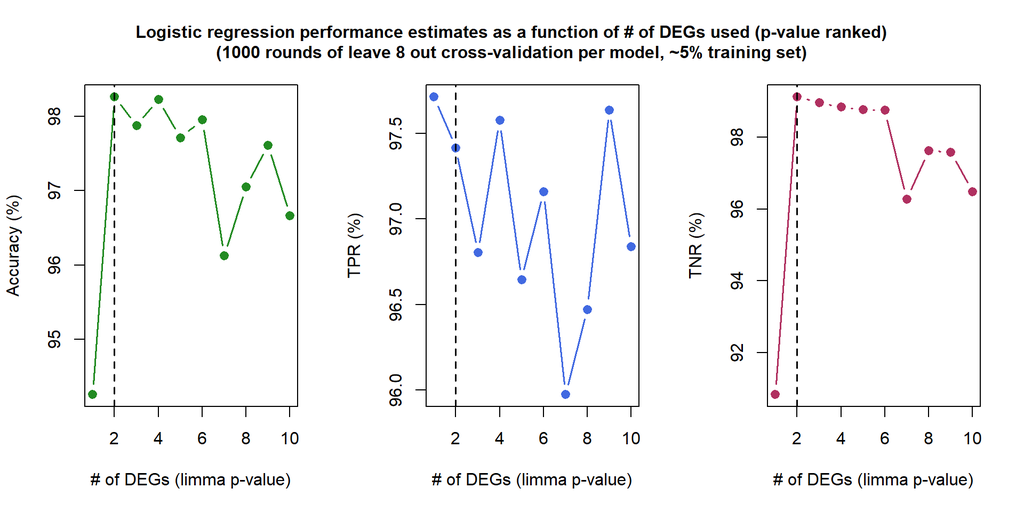

```r
## 1) Build a logistic regression model

## LR will probably need some form of feature selection because it is sensitive to correlated/redundant features

# Assesses performance via leave n out cross-validation for models with increase number of pre-ranked genes (p-values here)
try.features <- function(wrapper, DepdentSource, data.source, max.vars=5, var.names=NULL, verbose=FALSE, leave.out=5, N.run=1000, ...) {
  results <- list()
  n.genes <- if (is.null(var.names)) {max.vars} else {length(var.names)}
  for (i in 1:n.genes) {
    if (verbose) {
      cat(paste("CV run", i, "out of", n.genes, "\n"))
    }
    # Perform the cross-validation with the given number of DEGs to include in the training
    indices <- if (is.null(var.names)) {1:i} else {var.names[1:i]}
    cv.results <- cross.validate(wrapper, DepdentSource ~ ., data.source[, indices, drop=FALSE], n.out=leave.out, N=N.run, ...)
    results[[i]] <- assess.prediction(cv.results$truth, cv.results$prediction, print.results = FALSE)
  }
  pred.acc.df <- as.data.frame(do.call(rbind, results))
  if (is.null(var.names)) {
    rownames(pred.acc.df) <- colnames(data.source)[1:max.vars]
  } else {
    rownames(pred.acc.df) <- var.names
  }
  return(pred.acc.df)
}
pred.accuracy.df <- try.features(predictor.LR, SampleType.int, training.expr.sorted, max.vars=10, leave.out=floor(dim(training.expr.sorted)[1]*0.05))

## Visualize the performance estimates from the cross-validation (e.g. accuracy, sensitivity, specificity)
best.choice <- 2 # Where does it look like adding more variables/genes adds absolutely nothing?
plot.assessment.stats(results.df = pred.accuracy.df, x = 1:dim(pred.accuracy.df)[1],
                      title="Logistic regression performance estimates as a function of # of DEGs used (p-value ranked)\n(1000 rounds of leave 8 out cross-validation per model, ~5% training set)",
                      x.label = "# of DEGs (limma p-value)",
                      mid.line = best.choice, par.cex = 1.01)
```

As seen above, the accuracy, sensitivity, and specificity are all quite good when only the 2 top DEGs are included in the logistic regression (LR) model. Adding features past that point leads to some level of noise and what appears to be a loose downward trend in performance. While this is not shown, I originally went out to 20 variables and performance does start to drop off more steeply and uniformly. So it seems like fewer top DEGs is better, at least for this model and set of genes (which we know are pretty correlated).

That said, looking at the plot above I could not help but notice that some genes that come later appear to improve the performance notably, even after the model takes major dips from adding other genes before that. This got me wondering if there was a way to home in on the most useful variables among these top DEGs. I originally wrote code that identified which genes above led to increases in performance when they were added (above some threshold), and then tested a model with only those genes. The model made in this way did not lead to the expected cross-validation performance, and it makes sense in hindsight why it is not that simple. We only see the “desirable” genes’ positive impact above within the context of the other genes added to the model (whether helpful or not), which I think is why that naive approach I tried does not necessarily work. Based on the Week 6 lecture notes, I decided to give an AIC-based approach a try, as AIC can be applied with LR/generalized linear models. This was done below by writing code that first trains a model with the 7 top DEGs. I chose this number because too far past this point and the model training function was more likely to throw a “did not converge” warning, which I think may be explained by the number of strongly correlated features being added. The AIC for this first model (with all 7 variables) is saved in a list, and then a loop trains a model with each single variable removed, each time calculating and recording the AIC. The resulting AIC values were plotted, the idea being that since the goal is to minimize AIC, desirable variables are those that, when removed, increased the AIC above that of the model with all 7 variables. Less desirable variables decreased the AIC relative to the starting value (w/ all variables) when removed. The plot below enables this to be seen clearly.

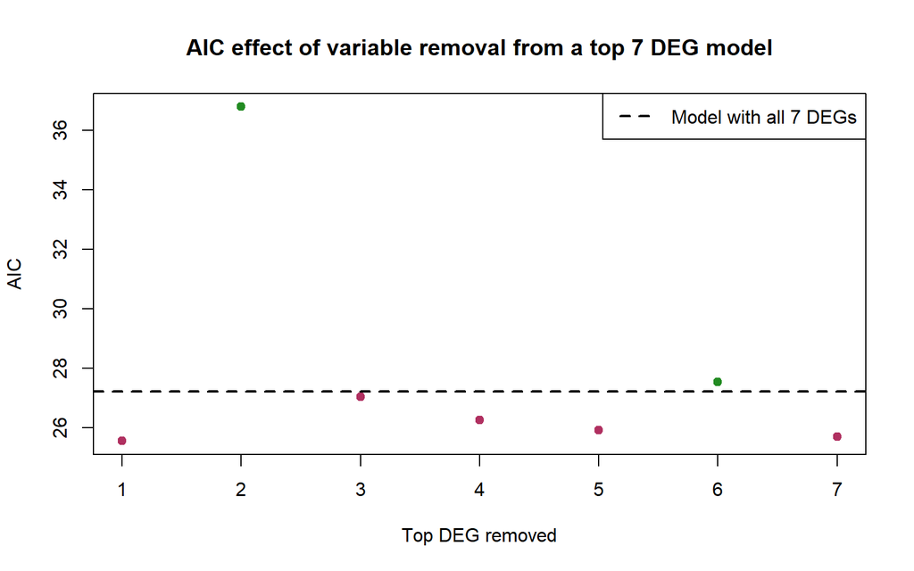

```r
# Check for most balanced variables by fitting an LR model with several DEGs and then

# pulling out variables one-by-one and seeing which have the worst effect on AIC
n.vars <- 7
indices <- 1:n.vars
predictor.LR$train(SampleType.int ~ ., training.expr.sorted[, indices, drop=FALSE])
aic.vals <- list(all=AIC(predictor.LR$model))
for (i in indices) {
  current.ind <- indices[indices!=i]
  predictor.LR$train(SampleType.int ~ ., training.expr.sorted[, current.ind, drop=FALSE])
  aic.vals[[paste(i)]] <- AIC(predictor.LR$model)
}
aic.vals <- as.numeric(aic.vals)

# Visualize the results for the AIC testing
plot(1:(length(aic.vals)-1), aic.vals[2:length(aic.vals)], pch=19, col=ifelse(aic.vals[2:length(aic.vals)]<aic.vals[1], "maroon", "forestgreen"),
     main="AIC effect of variable removal from a top 7 DEG model", xlab="Top DEG removed", ylab="AIC")
abline(h=aic.vals[1], lty=2, lwd=2)
legend(x="topright", legend=c("Model with all 7 DEGs"), lty=2, lwd=2)
```

As seen above, we have two clear winners: top DEGs number 2 and 6. These two genes negatively impacted the AIC of the model when removed, compared to the model with all 7 top DEGs. The plot above again supports that only ~2 genes among these top DEGs may be necessary for well-performing predictive model, in addition to pointing out which ones may be a good choice. That said, I tried models using only top DEGs 2 and 6 and while the performance was impressive, it was not typically quite as high as what often occurred in the first plot earlier when top DEGs 1 and 2 were used. Because of this, I decided to try a model with top DEGs 1, 2 and 6, and this led to a model that typically seemed to perform well across all 3 metrics. While I have set the seed now, I had not when working on this originally, and this model seemed to fare decently over the various reruns. The same functions defined and discussed earlier were used to cross-validate and visualize estimated performance for the models with one, two, or all three of these selected top DEGs added (1, 2, and 6):

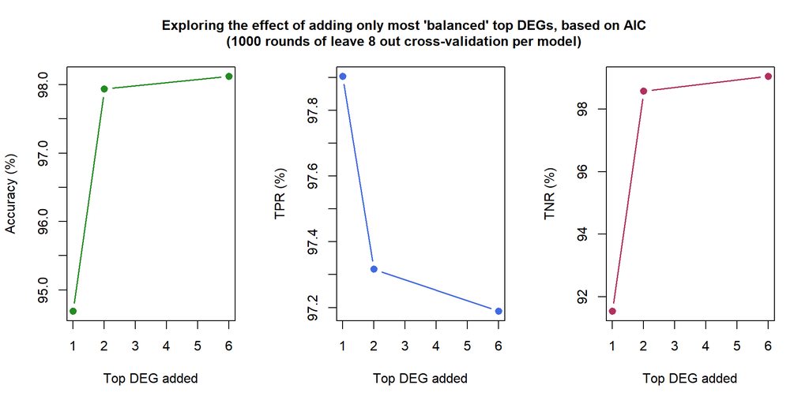

```r
## Visualize the performance estimates using the "AIC-removal" selected genes
pred.accuracy.df <- try.features(predictor.LR, SampleType.int, training.expr.sorted, var.names = colnames(training.expr.sorted)[c(1,2,6)], leave.out=floor(dim(training.expr.sorted)[1]*0.05))
plot.assessment.stats(results.df = pred.accuracy.df, x = c(1,2,6),
                      title="Exploring the effect of adding only most 'balanced' top DEGs, based on AIC\n(1000 rounds of leave 8 out cross-validation per model)",
                      x.label = "Top DEG added", par.cex = 1.01)
```

```r
# What is the correlation among the selected variables?
gene.correlations[colnames(training.expr.sorted)[c(1,2,6)], colnames(training.expr.sorted)[c(1,2,6)]]
```

```
##                 ENSG00000158966 ENSG00000136158 ENSG00000152583
## ENSG00000158966       1.0000000       0.8339359       0.8085701
## ENSG00000136158       0.8339359       1.0000000       0.7783797
## ENSG00000152583       0.8085701       0.7783797       1.0000000
```

```r
# What is the average correlation among the top 50 DEGs (by p-value)?
mean(get.tri(gene.correlations[colnames(training.expr.sorted)[1:50], colnames(training.expr.sorted)[1:50]]))
```

```
## [1] 0.7804187
```

```r
# Train and save the chosen model (for testing step later)
predictor.LR$train(SampleType.int ~ ., training.expr.sorted[, c(1,2,6), drop=FALSE])
# save(predictor.LR, file="predictor.LR.sv")
```

As seen above, the model with top DEGs 1, 2, and 6 does seem to perform well overall during cross-validation. It is worth noting that an LR model with many combinations of about 2 or 3 top significance DEGs could probably be used to get comparable performance, especially when the variability of cross-validation results relative to the narrow performance range being considered is taken into account. That said, this seems good enough. Remembering what was discovered about gene correlations in the exploration section, I checked the correlation among these chosen DEGs and sure enough it is pretty strong (~0.8 on average). Correlations of this strength may explain the notable instability/shifting that occurred from one cross-validation to another (especially in models with many DEGs tested earlier). While it was not so variable that it makes me distrust the conclusions drawn above, it seemed more obvious than for some of the other model types when working on this assignment. It also looks like we would not do much better by considering other sets of genes from among the top DEGs (without considering those with much higher p-values), as the average correlation even among the top 50 DEGs is still 0.78! This is all consistent with the findings from earlier about gene correlations among the DEGs. The final chosen LR model is trained above for the testing step later.

### Random forest

I can go about feature selection a little bit differently for a random forest (RF) model than I could for LR, because RF already identifies and uses the relevant features when building trees/training the model. Thus, I decided to train a random forest model on *all* training set DEGs and then investigate the trained model’s importance metrics for those DEGs. This is done below. First, the `randomForest()` is used to train a model to predict `sample_type` based on the entire training set. Then `get.perf()` (defined and discussed earlier) is used to extract and save the performance metrics from the OOB confusion table (used later). Separate cross-validation is not absolutely required for RF models as it is for the others, because something akin to leave one out cross-validation is performed during the model training process (so we just need to tap into those OOB results) [5]. The histogram of importance values to the model trained on all DEGs is plotted below for consideration.

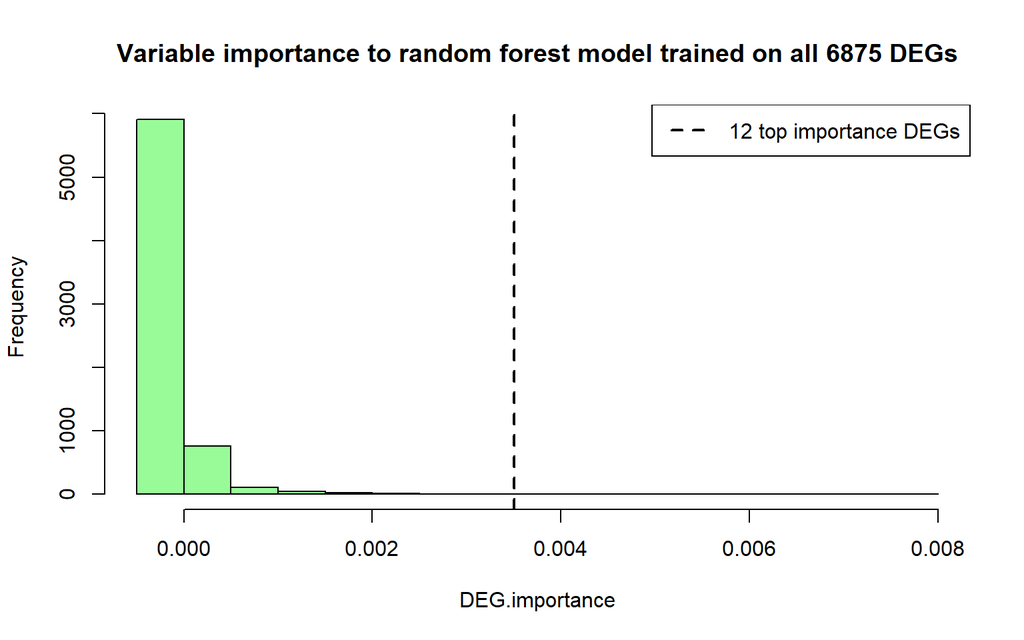

```r
## 2) Build a random forest model

## Fit a random forest using all DEGs, as a starting point for thinning to fewer important ones (pre parameter optimization)
# for "mtry" using the default heuristic of ~sqrt(n.vars) for classification
RF.all.DEGs <- randomForest(as.factor(SampleType.int) ~., data=training.expr.sorted, importance=TRUE, na.action="na.exclude")
perf.list <- list()
perf.list[[paste("All",  dim(training.expr.sorted)[2], "DEGs")]] <- get.perf(RF.all.DEGs, print.results = FALSE)
DEG.importance <- RF.all.DEGs$importance[,"MeanDecreaseAccuracy"]

## Visualize the distribution of importance values from the RF model
imp.cutoff <- 0.0035
hist(DEG.importance, main=paste("Variable importance to random forest model trained on all",  dim(training.expr.sorted)[2], "DEGs"), col="palegreen")
abline(v=imp.cutoff, lty=2, lwd=2)
legend(x="topright", legend=paste(sum(DEG.importance>=imp.cutoff),"top importance DEGs"), lty=2, lwd=2)
```

As seen above, somewhat unsurprisingly, the vast majority of DEGs are of little to no relative importance to an RF model trained on all DEGs for predicting `sample_type`. As few as 12 DEGs have importance values that are each at least several times more important that any of the others. As such, it seems like we can save the model some training time by only providing those important DEGs in the training data, which will help when attempting to optimized the RF parameters later (faster run times). That said, I wanted to make sure that similar performance is achieved by the model when only these genes are provided, so I trained another RF model with only the top 10 importance DEGs and then used `get.perf()` and `comparison.chart()` (both defined and discussed earlier) to compare the performance of that model to the one that had access to *all* DEGs during training:

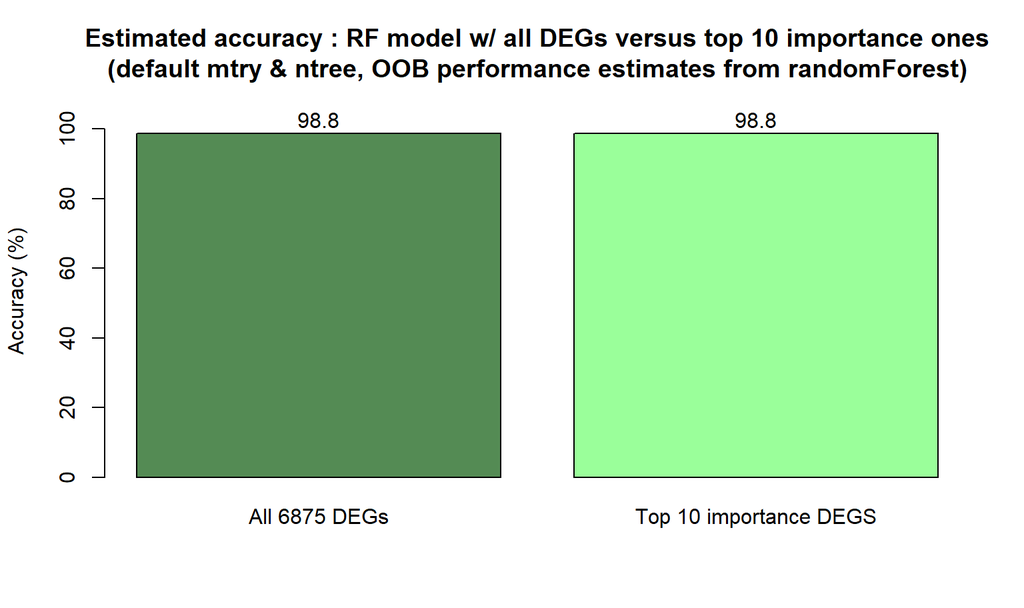

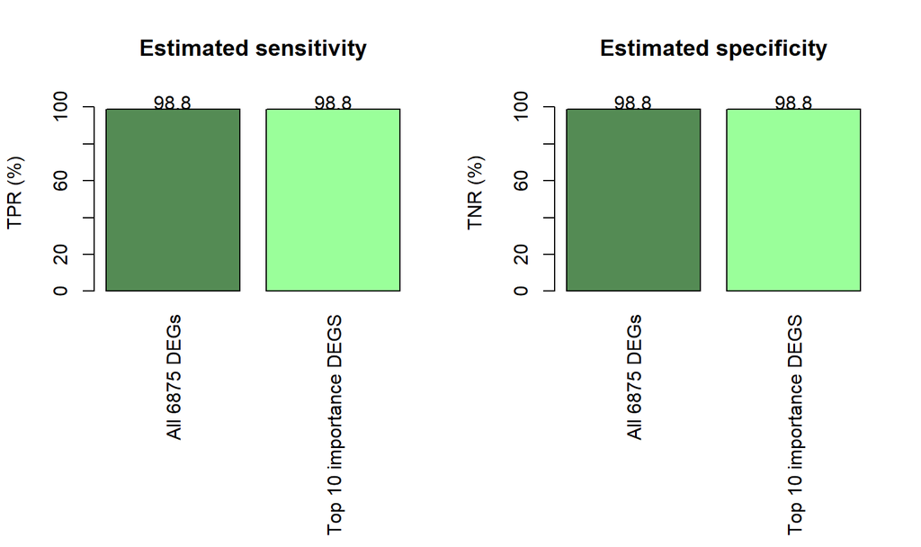

```r
## Based on the variable importance will move forward optimizing parameters with just top 10 importance DEGs
new.vars <- names(DEG.importance)[rank(-DEG.importance)<=10]
RF.imp.vars <- randomForest(as.factor(SampleType.int) ~., data=training.expr.sorted[, new.vars, drop=FALSE], importance=TRUE, na.action="na.exclude")
perf.list[["Top 10 importance DEGS"]] <- get.perf(RF.imp.vars, print.results = FALSE)

## Visualize the results of RF model with all DEGs and just the top importance ones
# Make the plots of estimated accuracy, sensitivity, and specificity
colors <- c("palegreen4", "palegreen1")
title <- ": RF model w/ all DEGs versus top 10 importance ones\n(default mtry & ntree, OOB performance estimates from randomForest)"
comparison.chart(perf.list, metric = "accuracy", colrz=colors,
                 title=paste("Estimated accuracy", title)[[1]])
par(mfrow=c(1,2), mar=c(11, 4, 4, 2) + 0.1)
comparison.chart(perf.list, metric = "TPR", colrz=colors,
                 title="Estimated sensitivity", par.las=3)
comparison.chart(perf.list, metric = "TNR", colrz=colors,
                 title="Estimated specificity", par.las=3)
par(mfrow=c(1,1), mar=c(5, 4, 4, 2) + 0.1)
```

Finally, I wanted to explore whether `mtry` and `ntree` could be optimized now that the size (i.e. features) included in the training set could be reduced. The nested loop below simply tries all combinations of a range of values for `mtry` and `ntree` during training and saves the corresponding OOB error rates. The values chosen for `ntree` were somewhat arbitrary, but based on what I have gathered from this course and the `randomForest` documentation, it seems to be a comprehensive range. As for `mtry`, I probably did not need to use an increment of 1, but the values cover the full possible range which is clearly bounded. The minimum of 1 essentially causes completely random variable selection at each split, while `mtry` equal to the number of variables is the same as bagging (not really RF) [5].

```r
## Try optimizing ntrees and mtry with this new smaller number of variables (faster)
ntrees.vals <- c(25,50,100,200,400,800,1600)
mtrys <- c(1:length(new.vars))
opt.results <- matrix(nrow=length(mtrys), ncol=length(ntrees.vals))
rownames(opt.results) <- mtrys
colnames(opt.results) <- ntrees.vals
for (i in 1:length(mtrys)) {
  for (j in 1:length(ntrees.vals)) {
    RF.tmp <- randomForest(as.factor(SampleType.int) ~., data=training.expr.sorted[, new.vars, drop=FALSE], mtry=mtrys[i], ntrees=ntrees.vals[j], importance=FALSE, na.action="na.exclude")
    opt.results[i,j] <- RF.tmp$err.rate[dim(RF.tmp$err.rate)[1],1]
  }
}
# Results from parameter optimization: ROWS = mtry & COLUMNS = ntree
opt.results
```

```
##            25         50        100        200        400        800       1600
## 1  0.01176471 0.01176471 0.01176471 0.01176471 0.01176471 0.01176471 0.01176471
## 2  0.01176471 0.01176471 0.01176471 0.01176471 0.01176471 0.01176471 0.01176471
## 3  0.01176471 0.01176471 0.01176471 0.01176471 0.01176471 0.01176471 0.01176471
## 4  0.01176471 0.01176471 0.01176471 0.01176471 0.01176471 0.01176471 0.01176471
## 5  0.01176471 0.01176471 0.01176471 0.01176471 0.01176471 0.01176471 0.01176471
## 6  0.01176471 0.01176471 0.01176471 0.01176471 0.01176471 0.01176471 0.01176471
## 7  0.01176471 0.01176471 0.01176471 0.01176471 0.01176471 0.01176471 0.01176471
## 8  0.01176471 0.01176471 0.01176471 0.01176471 0.01176471 0.01176471 0.01176471
## 9  0.01176471 0.01176471 0.01176471 0.01176471 0.01176471 0.01176471 0.01176471
## 10 0.01176471 0.01176471 0.01176471 0.01176471 0.01176471 0.01176471 0.01176471
```

```r
## Optimization results imply OOB performance (using these genes) is completely
# insensitive to the choice of mtry and ntree, will stick with the defaults
# Training and saving the final model
RF.final <- RF.imp.vars
# save(RF.final, file="RF.final.sv")
```

As seen above, for this set of features the OOB error rate was insensitive to changing both `mtry` and `ntree`. This is not too surprising based on what I have read about RF models and the fact that performance was already excellent. I am also aware that by narrowing the number of features provided to only a few already determined to be most important by an RF model, I may have limited the ability of these parameters to make a difference. This optimization could easily be performed on a model trained with many more DEGs/features, but it would have taken much longer. Also, based on some trial-and-error (not shown), I think the best that would have occurred by doing so, for *this* data set, would have been comparable or only marginally better performance at the optimum (to what was achieved above). As as such, I called this model “good enough” and saved it for the final testing. After working on the RF models above, it seems like the popularity of RF models may largely stem from the fact that they are relatively “low-maintenance” to build.

### Support vector machine

Below, I begin the same way I did with the LR model, by training radial kernel support vector machine (SVM) classifiers with an incrementally increasing number of top significance DEGs up to 10 (using a function defined and discussed earlier). The performance estimates from cross-validation are then plotted using another function defined earlier:

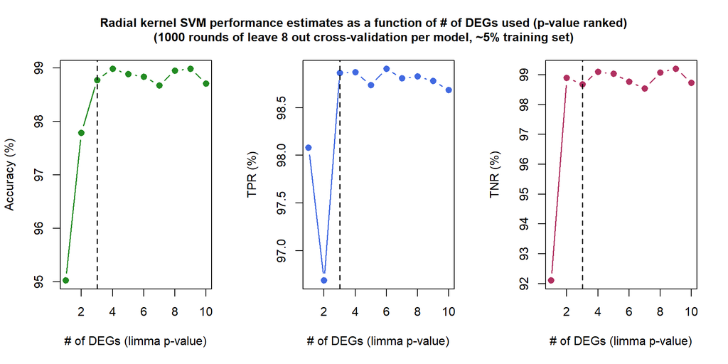

```r
## 3) Build an SVM model

# Using the function from earlier to step-wise add the top 10 DEGs to the model (and cross-validate)
pred.accuracy.df <- try.features(predictor.SVM, SampleType.factor, training.expr.sorted, max.vars=10, leave.out=floor(dim(training.expr.sorted)[1]*0.05))

## Visualize the performance estimates from the cross-validation (e.g. accuracy, sensitivity, specificity)
best.choice <- 3 # Where does it look like adding more variables/genes adds absolutely nothing?
plot.assessment.stats(results.df = pred.accuracy.df, x = 1:dim(pred.accuracy.df)[1],
                      title="Radial kernel SVM performance estimates as a function of # of DEGs used (p-value ranked)\n(1000 rounds of leave 8 out cross-validation per model, ~5% training set)",
                      x.label = "# of DEGs (limma p-value)",
                      mid.line = best.choice, par.cex = 1.01)
```

As seen above, there seems to be a saturation point such that there is little to no meaningful/reliable improvement to the estimated model performance gained by including genes beyond the ~3 top significance DEGs. This is consistent with the findings from other models so far that very few DEGs are needed to make an accurate predictive model for `sample_type` here. I did not include this earlier, but I have reason to believe the final RF model does not necessarily need all 10 top importance DEGs either (but it is not hindered by them).

Now that a number of features have been selected, the impact of perhaps the two most important parameters for a radial kernel SVM are considered: `gamma` and `cost.` As discussed in Week 6, `gamma` controls the data points that can impact the separating hyperplane, with high values of `gamma` allowing only the closest point(s) to dictate the plane and smaller values allowing points that are farther away to be considered together. The former scenario could clearly lead to overfitting of the hyperplane around the specific quirks/noise of the data. The `cost` parameter tunes how severely violations to the margin are penalized during model training, so small values lead to wide margins and large values result in narrow margins [6]. Once again, this seems like a parameter that probably could lead to overfitting of some kind if pushed to far on one direction, thus resulting in poor performance during cross-validation. The loop below is very similar to the one at the heart of `try.features()`, except the DEGs/variables used during cross-validation remain constant (top 3 DEGs, as determined above) while the value of `gamma` ultimately passed to `svm()` is changed on each iteration. The performance results for different values of gamma are again visualized using `plot.assessment.stats()` below:

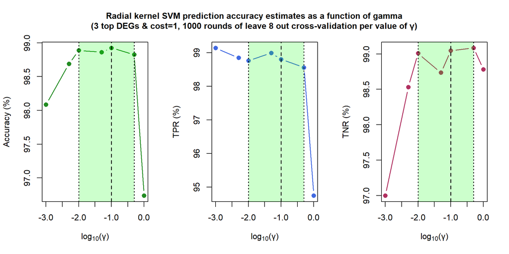

```r
# There are others, but probably the most impactful parameters are gamma and cost:

# Ideally should optimize both at once, but will do one at a time for resource/time considerations
# also the noisiness of the results I am getting on each rerun makes a heatmap/full-factorial less interpret able/trustworthy
gammas = c(0.001, 0.005, 0.01, 0.05, 0.1, 0.5, 1) # Values of gamma to try (1/3 is in this range)
results <- list()
# Perform gamma optimization with set number of top DEGs (3) and default cost
for (i in 1:length(gammas)) { # Perform the cross-validation with each value of gamma for the SVM model
  # gamma can simply be passed as an argument to cross.validate()
  # (it will make it to svm() call in the additional parameters "...")
  cv.results.SVM.temp <- cross.validate(predictor.SVM, SampleType.factor ~ ., training.expr.sorted[, 1:3, drop=FALSE], n.out=floor(dim(training.expr.sorted)[1]*0.05), gamma=gammas[i])
  results[[i]] <- assess.prediction(cv.results.SVM.temp$truth, cv.results.SVM.temp$prediction, print.results = FALSE)
}
pred.accuracy.df <- as.data.frame(do.call(rbind, results))

## Visualize the performance estimates from the cross-validation (e.g. accuracy, sensitivity, specificity)
plot.assessment.stats(results.df = pred.accuracy.df, x = log10(gammas),
                      title=paste("Radial kernel SVM prediction accuracy estimates as a function of gamma\n(", 3, " top DEGs & cost=1, 1000 rounds of leave 8 out cross-validation per value of γ)", sep="")[[1]],
                      x.label = expression("log"[10]*"(γ)"),
                      min.line = log10(0.01),
                      max.line = log10(0.5),
                      mid.line = log10(0.1),
                      par.cex = 1.01)
```

Next, a range of values for `cost` are tested at a constant `gamma` of 0.1 with the 3 top DEGs as variables. The heart of the code below is identical in structure to the chunk just discussed above for optimizing `gamma`, so I will not discuss it further.

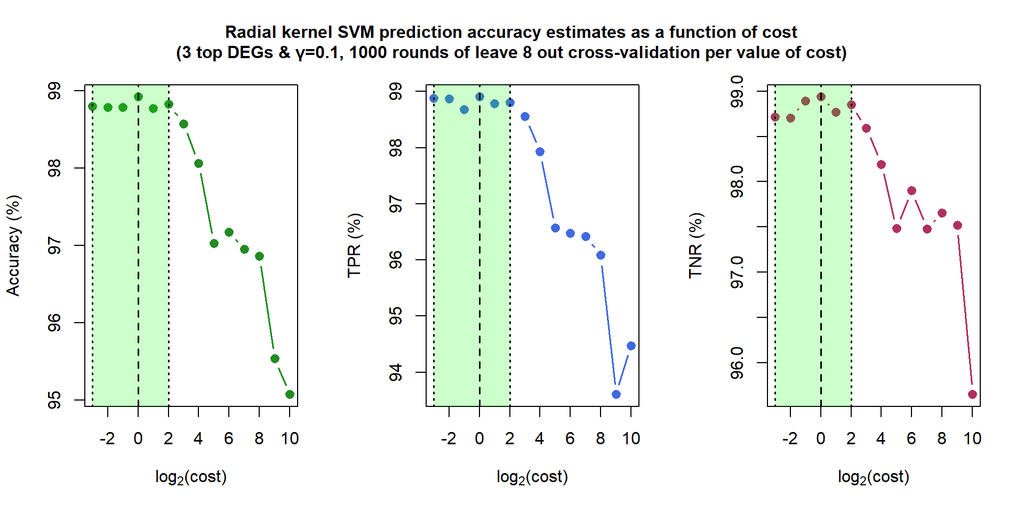

```r
# Next optimize the cost at the the chosen value of gamma (not ideal)
cost.vals = c(0.125, 0.25, 0.5, 1, 2, 4, 8, 16, 32, 64, 128, 256, 512, 1028) # Values of cost to try
results <- list()
# Perform optimization with set number of top DEGs (3)
for (i in 1:length(cost.vals)) { # Perform the cross-validation with each value of cost for the SVM model
  # cost can simply be passed as an argument to cross.validate()
  # (it will make it to svm() call in the additional parameters "...")
  cv.results.SVM.temp <- cross.validate(predictor.SVM, SampleType.factor ~ ., training.expr.sorted[, 1:3, drop=FALSE], n.out=floor(dim(training.expr.sorted)[1]*0.05), gamma=0.1, cost=cost.vals[i])
  results[[i]] <- assess.prediction(cv.results.SVM.temp$truth, cv.results.SVM.temp$prediction, print.results = FALSE)
}
pred.accuracy.df <- as.data.frame(do.call(rbind, results))

## Visualize the performance estimates from the cross-validation (e.g. accuracy, sensitivity, specificity)
plot.assessment.stats(results.df = pred.accuracy.df, x = log2(cost.vals),
                      title=paste("Radial kernel SVM prediction accuracy estimates as a function of cost\n(", 3, " top DEGs & γ=0.1, 1000 rounds of leave 8 out cross-validation per value of cost)", sep="")[[1]],
                      x.label = expression("log"[2]*"(cost)"),
                      min.line = log2(0.125),
                      max.line = log2(4),
                      mid.line = log2(1),
                      par.cex = 1.01)

# While far from an exhaustive optimization, it seems that gamma ~0.1 (not far from default)
# and the default cost=1 are safe bets for parameters
# Train and save the final SVM model for testing later
predictor.SVM$train(SampleType.factor ~ ., training.expr.sorted[, 1:3, drop=FALSE], cost=1, gamma=0.1)
# save(predictor.SVM, file="predictor.SVM.sv")
```

Again, we have an approximate range 0.125 to 4 in which the specific value of `cost` chosen does not matter much for performance. Increasing the `cost` much past 4 results in severe declines in estimated classification performance metrics across the board. This again makes sense, as overly narrow margins for an SVM classifier seem like overfitting, which will show itself as poor performance during cross-validation. The default value of 1 for `cost` seems to be a safe bet, as it is near the middle of this range of costs that yield comparable (maximum) performance.

I am aware that optimizing `gamma` for one value of `cost` and `cost` for one value of `gamma` is far from a comprehensive parameter optimization. The optimal value of one probably effects the optimal value of another, so ideally a full optimization surface would be constructed by considering all combinations of ranges of both parameters (as was done for `mtry` and `ntree` earlier). I decided not to do this because of time constraints, the fact that model performance is already looking excellent, and the fact that cross-validation results are jittery and we are looking for pretty small improvements to performance (meaning that here, such a surface may not be as useful/interpretable able as it sounds). Given my approach, I think it comes as little surprise that the “optimal” values found above are pretty close to the defaults that would be used by `svm()` without any tinkering (and these detaults were used when selecting the best features among the top DEGs). All that said, this model was deemed “good enough” and is trained above for testing along with the other models later.

### Neural network

For the neural network (NN) classifier, I again used `try.features()` to cross-validate models with top significance DEGs added incrementally (up to 10). As in the Week 6 lecture notes, I kept the number of vertices/neurons in the hidden layer equal to half of the number of predictive variables or 5, whichever was lower. For a maximum of 10 variables, this rule meant that the number of hidden vertices was always equal to half of the number of top DEGs used as inputs (rounded down). While I could have tried to optimize the size of the hidden layer further, when playing with this model, I noticed that increasing this number much past low values resulted in *significant decreases* in the estimated performance from cross-validation. This was true regardless of the number of features chosen, although including too many genes also hurt performance notably. Thus, the provided heuristic seemed to be the safest bet here. I will discuss this in more detail below. The results of the cross-validations are visualized below, again using `plot.assessment.stats()`.

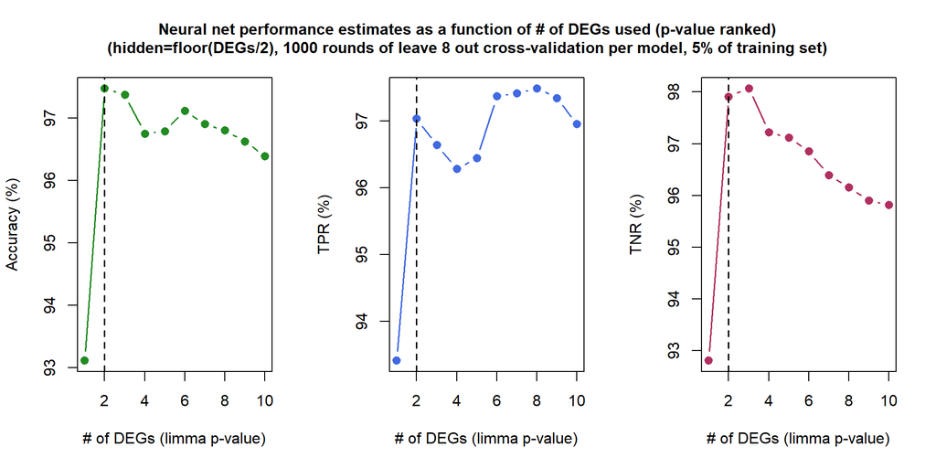

```r
## 4) Build a neural network model

# Using the function from earlier to step-wise add the top 10 DEGs to the model (and cross-validate)
# rep = 1 (already repeating during cross-validation), hidden=min(dim(data)[2] %/% 2, 5), linear.output=FALSE
pred.accuracy.df <- try.features(predictor.NN, SampleType.int, training.expr.sorted, max.vars=10, leave.out=floor(dim(training.expr.sorted)[1]*0.05), verbose=FALSE, hidden=min(dim(data)[2] %/% 2, 5), linear.output=FALSE, rep=1)

## Visualize the performance estimates from the cross-validation (e.g. accuracy, sensitivity, specificity)
best.choice <- 2 # Where does it look like adding more variables/genes adds absolutely nothing?
plot.assessment.stats(results.df = pred.accuracy.df, x = 1:dim(pred.accuracy.df)[1],
                      title="Neural net performance estimates as a function of # of DEGs used (p-value ranked)\n(hidden=floor(DEGs/2), 1000 rounds of leave 8 out cross-validation per model, 5% of training set)",
                      x.label = "# of DEGs (limma p-value)",
                      mid.line = best.choice, par.cex = 1.01)

# It seems that, much like prior models, the most robust choice is to use ~2 top DEGs
# While I could optimize neurons for the hidden layer, the heuristic actually seemed to work best
# as increasing hidden at all made the performance drop across the board regardless of the number of DEGs
# Train and save the final model for later
predictor.NN$train(SampleType.int ~ ., training.expr.sorted[, 1:2, drop=FALSE], hidden=1, linear.output=FALSE, rep=1)
# save(predictor.NN, file="predictor.NN.sv")
```

Much like the other models, it seems that with the neural network model fewer top DEGs as predictive variables is better and the optimum for overall performance is ~2 top significance DEGs. It should be noted that while sensitivity appears to have an obvious peak later on, that feature was not stable back when I did not set the seed. Besides, even if it were, the drop in the other 2 metrics is not worth it. It is worth noting that all three metrics dropped off steeply as the model grew when I used 20 as the maximum number of DEGs (not shown), and the start of this trend can be seen above. As discussed earlier, the decline in performance brought on by adding too many DEGs to the model was accelerated very notably by increasing the number of vertices in the hidden layer at all from the current values (half the number of features rounded down). This discouraged me from trying to optimize the size of the hidden layer further, as the optimal number of top DEGs always seemed to be ~2, and so there was little freedom to change the hidden layer (as increasing its size was not a viable option). As discussed in Week 6, even a relatively simple feedforward neural network is capable of modeling a level of complexity that is often excessive for relatively small data sets like this one. Right out of the gate, this model is “too flexible” and easily overfits the training data, leading to poor generalization (i.e. bad performance during cross-validation). Increasing the size and/or number of hidden layers would only increase this complexity, along with the model’s propensity to overfit. In the end, I saved the trained neural net with 2 top significance DEGs as inputs and 1 neuron in the hidden layer for comparison to the other models next.

## Testing

In the code below, the test data set is first prepared for use with `predict()` by transposing. The test samples and expression data were already set aside earlier before beginning the model development and training (see the start of the *Model development* section). The truth values for the test set are then retrieved and prepared from the patient metadata (as factor and integer vectors). The test performance results are collected in a list by calling the wrappers’ predict function (or `predict()` directly for RF) to have the trained models make predictions on the new/test data and calculate the corresponding performance metrics using `assess.prediction()` (and the truth values). Due to a quirk of how I trained the RF model earlier, its predictions needed to be converted to integers (1s and 0s) before assessment in order to avoid accidental perfect reversal of predictions relative to the truth values prepared below. Finally, the `comparison.chart()` function is called to create and format 3 bar charts to compare the accuracy, sensitivity, and specificity of the 4 models. The code behind the wrappers and functions used below was defined and discussed earlier in the *Training & optimization* section.

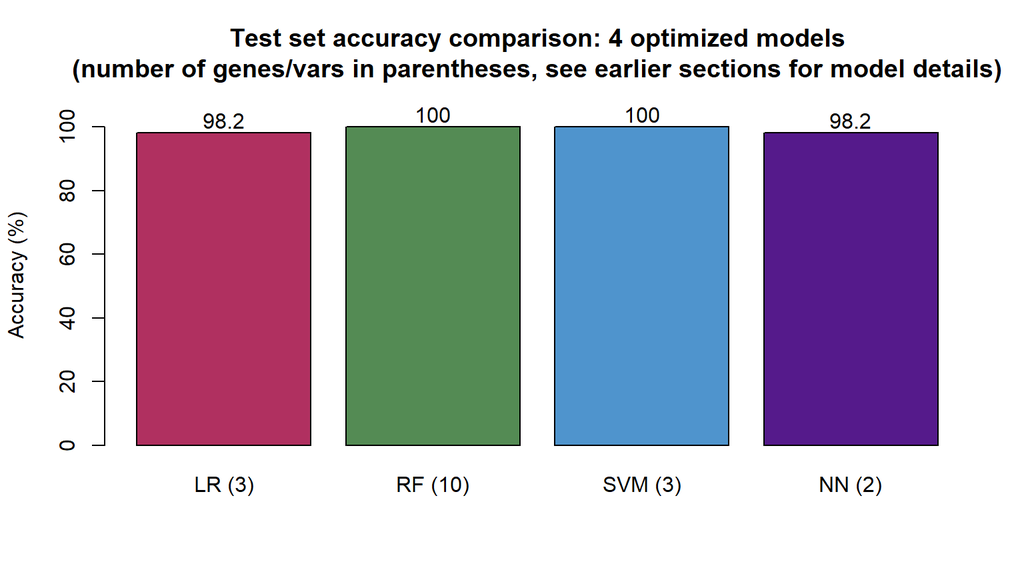

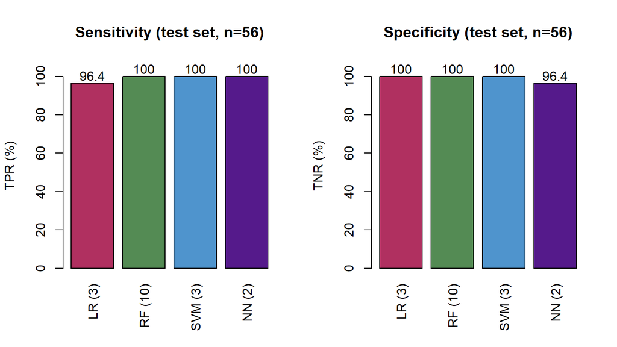

```r
# Prepare the test data set to be ordered by DEG p-value
# Sort the training data by DEG adjusted p-values
test.expr.t <- as.data.frame(t(test.expr))

# Get the truth values for the test samples randomly selected earlier
SampleType.char.test <- patient.meta[test.samples, "sample_type"]
SampleType.factor.test <- as.factor(SampleType.char.test)
SampleType.int.test <- ifelse(as.integer(as.factor(SampleType.char.test))==1, 1, 0) # encode as an integer


# Get the performance on the data these models have never seen (including DEG calculation!)
test.results <- list("LR (3)"=assess.prediction(SampleType.int.test, predictor.LR$predict(test.expr.t)),
                     # Explicit conversion needed due to how RF model was trained and now returns the predictions
                     "RF (10)"=assess.prediction(SampleType.int.test, as.integer(predict(RF.final, test.expr.t))-1),
                     "SVM (3)"=assess.prediction(SampleType.factor.test, predictor.SVM$predict(test.expr.t)),
                     "NN (2)"=assess.prediction(SampleType.int.test, predictor.NN$predict(test.expr.t)))


## Visualize the performance of all trained models on the testing set
# Make the plots of estimated accuracy, sensitivity, and specificity
colors <- c("maroon","palegreen4", "steelblue3", "purple4")
title <- "comparison: 4 optimized models\n(number of genes/vars in parentheses, see earlier sections for model details)"
comparison.chart(test.results, metric = "accuracy", colrz=colors,
                 title=paste("Test set accuracy", title)[[1]])
par(mfrow=c(1,2), mar=c(5, 4, 4, 2) + 0.1)
comparison.chart(test.results, metric = "TPR", colrz=colors,
                 title="Sensitivity (test set, n=56)", par.las=3)
comparison.chart(test.results, metric = "TNR", colrz=colors,
                 title="Specificity (test set, n=56)", par.las=3)
par(mfrow=c(1,1), mar=c(5, 4, 4, 2) + 0.1)
```

All 4 models performed very well on the test set. This is encouraging because I do not think models were directly influenced by this information in any way during model development/training. Even the DEGs were determined independently, as I reran the DEA using just the training data when working on these models. While all models performed very well, the RF and SVM models each performed perfectly on this test set with 100% accuracy, specificity, and sensitivity. The LR model had 98.2% accuracy and 96.4% sensitivity because it failed to identified a single tumor sample (i.e. classified it as normal). That said, it had 100% specificity because it did not classify any normal samples as tumor samples. The neural net model had the inverse issue, with 98.2% accuracy, 96.4% specificity, and 100% sensitivity due to the fact that it classified one normal sample as a tumor sample, but did not miss any tumor samples. I was hopeful that all of these models would perform well because the performance estimates were good during cross-validation of the optimal models (at least of those considered). I think the LR and NN models performed slightly worse than the others because of two issues discussed throughout this course and touched on earlier. The ability of a logistic regression model to perform well on new data is clearly affected by strongly correlated predictive variables, which are clearly plentiful among these DEGs. This was seen in the data exploration section and even when developing the model, as the 3 top DEGs chosen for the LR model were each correlated with the others with a strength of roughly 0.8. Perhaps I should have dropped one of those variables, as there was evidence that 2 may have sufficed. That said, I think the LR model would likely have run into this type of issue regardless of the specific DEGs chosen, as so many of the top ones are somewhat strongly or very strongly correlated. I think the NN model did not do as well as the SVM and RF models in the test set due to its propensity to overfit the training data. This was touched upon earlier when discussing the development of that model. Only 2 top DEGs and 1 vertex (in a single hidden layer) was used, which is a *very* simple model by neural network standards. That said, this relative simplicity was quite necessary for this application and data set, as cross-validation revealed that anything more complex (e.g. more variables and/or a larger hidden layer) resulted in stronger overfitting and poorer ability generalize to new data (i.e. high bias and low variance). Even though this model was kept as simple as was necessary, I think the performance above in the test set is indicative that it still slightly overfit the training data. So, I think the LR and NN models struggled slightly due to the nearly ubiquitous presence of many highly correlated features (which I did not avoid selecting during model development) and an overly complex model structure, respectively. The RF and SVM models did not have these issues. During earlier assignments in this course, it has been clear that these two types of models are not extremely sensitive to correlated features or overfitting, although overfitting is still certainly possible. From some research I did while participating in the class discussion about these models, I have come to think that RF and SVM models, when used at least vaguely correctly, tend to perform comparably for typical biological/biomedical data sets. This is of course a broad generalization, but most of the benchmarking studies and reviews I skimmed that considered both of these types of models ultimately assigned them either nominally similar performance or significantly but not impressively different performance. I am sure they each have their applications/contexts where one outshines the other, but it seems like often times either one is a reasonable choice for this type of data set if used somewhat thoughtfully.

One thing I was curious about while working on these models was which genes tended to be useful across models. Of course, many of the model’s predictive variables are identical because they were selected from the same list of top DEGs (by p-value). That said, the RF model selected its own important variables from among all the DEGs, so I was curious how these intersect with the ones chosen by significance rank and cross-validation alone. Below I map the Ensembl IDs for the variables of each model to gene symbols using `org.Hs.eg.db` and then find genes that are common across models:

```r
## How do the DEGs used by these models compare?
library("org.Hs.eg.db")
LR.vars <- suppressMessages(select(org.Hs.eg.db, colnames(training.expr.sorted)[c(1,2,6)], columns=c("SYMBOL"), keytype = "ENSEMBL")$SYMBOL)
LR.vars # Logistic regression (lowest p-values):
```

```
## [1] "CACHD1"  "SPRY2"   "SPARCL1"
```

```r
RF.vars <- suppressMessages(select(org.Hs.eg.db, new.vars, columns=c("SYMBOL"), keytype = "ENSEMBL")$SYMBOL)
RF.vars # Random forest (highest importance):
```

```
##  [1] "SPRY2"   "MATN2"   "MME"     "ADAMTS5" "VEGFD"   "MAMDC2"  "CAVIN2"
##  [8] "HOXA5"   "MMP11"   "ITM2A"
```

```r
SVM.vars <- suppressMessages(select(org.Hs.eg.db, colnames(training.expr.sorted)[1:3], columns=c("SYMBOL"), keytype = "ENSEMBL")$SYMBOL)
SVM.vars # Support vector machine (lowest p-values):
```

```
## [1] "CACHD1" "SPRY2"  "MATN2"
```

```r
NN.vars <- suppressMessages(select(org.Hs.eg.db, colnames(training.expr.sorted)[1:2], columns=c("SYMBOL"), keytype = "ENSEMBL")$SYMBOL)
NN.vars# Neural net (lowest p-values):
```

```
## [1] "CACHD1" "SPRY2"
```

```r
# Which gene(s) do they all use?
Reduce(intersect, list(LR.vars, RF.vars, SVM.vars, NN.vars))
```

```
## [1] "SPRY2"
```

```r
# What was the fold change in the tumor samples (all data) for SPRY2?
DEGsCoding[new.vars[1], 1:5]
```

```
##                    logFC  AveExpr         t      P.Value    adj.P.Val
## ENSG00000136158 -17.9823 13.09735 -27.19348 4.801228e-73 6.387554e-69
```

As seen above, the only gene selected for use in all models was *SPRY2*. This gene was among the most important predictive variables for the RF model trained on all DEGs and also stood out as the most important during the AIC-based variable selection (via elimination) for the LR model. *SPRY2* has been proposed as a prognostic biomarker in breast cancer, with reduced expression associated with poorer survival odds [7]. More recently, another study not only reaffirmed the association of decreased *SPRY2* expression with poorer prognosis, but also found that *SPRY2* negatively regulates cancer-associated fibroblast activation and is a potential therapeutic target [8]. Knockdown of *SPRY2* in the fibroblasts of mice led to increased tumor growth and metastasis [8]. This type of support from the literature is always encouraging to see! One or two other genes used by the RF model initially jumped out to me as being familiar and associated with breast cancer. For example, there is a VEGF gene: *VEGFD*. The growth factors encoded by such genes, along with their receptors, are fairly well-established as important to breast cancer progression, and may even be useful biomarkers and/or therapeutic targets [9]. Associations with breast cancer have also been observed for *MAMDC2* [10], and I would not be surprised if the same were true for many other genes above that I am not familiar with.

# **Extra credit**

*Note: I did not have time to write code for concisely displaying multi-class performance metrics from multiple models on one chart/plot for easy comparison. As such, the performance of each model is simply printed out in tabular format.*

## Development

Based on the PCA conducted in the data exploration section, aside from tumor/normal, the only other distinction that this data set seems to readily/easily support is some level of classification of the tumor samples by disease subtype (see the PCA plot for `paper_BRCA_Subtype_PAM50`). From that PCA plot, it seems like the best that can be done reliably is perhaps distinguishing Basal tumors from the rest. That said, there may be some capacity to also identify Luminal A cases. As stated earlier, the Basal breast cancer subtype is typically associated with the highest-risk [4], so even if the model can only give a reliable yes/no for this subtype, it may have some value. I will start by developing a model aiming to classify all subtypes, and then go from there based on what seems feasible. I chose to use an RF classifier for this part, as opposed to SVM, as RF readily handles more than two classes. I thought about training multiple one-versus-rest SVM models and combining their predictions to make the final prediction, but I did not have the time for that. At this point, LR and NN classifiers were off the table due to their limitations in this context, discussed earlier, which I did not want to navigate while exploring this question.

In the code below, a new seed is first set and the data is divided into training and testing sets. Because there are multiple classes, with some having much fewer cases, and the only samples being considered are tumor samples, the process of randomly sampling to develop a testing set with all classes represented was a little bit more complicated. That said, I ultimately took the same approach as before and randomly sampled a proportion (here 25%) of the sample IDs from each class, finally recombining the draws from all classes to make the test set. The tumor samples left out of the test set were then selected as the training set. This was all done using a series of named lists and loops (or loop stand-in functions). It should be noted that the Her2 and Normal-like subtypes had very few cases, and so those classes largely dictated the sampling proportion that could be used. Due to the limited number of samples for these classes, I expect performance to be poor and they are included mainly for completeness. The IDs of the test and training samples are used to extract the relevant expression data into separate data frames, and to create the vectors of those samples’ true subtype labels (from the patient meta data). Next, in order to identify which genes should be used initially by the RF model, I wrote a loop that uses `TCGAanalyze_DEA()` to conduct a one-versus-rest differential expression analysis for each disease subtype. While not necessarily ideal, I figured this was a quick and easy way to at least get some genes that differentiate each class from the others. A list of all potentially useful genes was then created by taking the union of the lists of DEGs from each disease subtype (versus the others). An RF model was then trained with default parameters on all of these DEGs/“useful” genes. I wrote a function called `get.perf.multi.class()` which extracts the confusion matrix from a trained RF model and computes the performance metrics (much like `get.perf()` from earlier, but for a multi-class confusion matrix). Finally, this function is used to asses the OOB performance of the RF model trained using the list of all potentially useful DEGs as variables (as defined above).

```r
## Decided to try to make a model that can predict cancer subtype
# this is based on the observations from PCA in the data exploration

# Make a new training and testing sets
set.seed(31117532) # New seed

# Now I am considering ONLY the tumor samples
# Based on PCA this data set seems to only have info to differentiate Basal and LumA
# at best, but will try including all classes at first just to see (Her2 and Normal-like have limited cases)
# Once again, I build the test set by taking the same proportion of each class as a random sample
# and then recombining the randomly selected samples from all classes
subtype <- patient.meta$paper_BRCA_Subtype_PAM50
names(subtype) <- rownames(patient.meta)
not.na <- !is.na(subtype)
tumor.samples <- rownames(patient.meta)[patient.meta$sample_type=="Primary Tumor"]
classes <- levels(as.factor(subtype))
class.samples <- lapply(classes, function(class) rownames(patient.meta)[patient.meta$sample_type=="Primary Tumor" & subtype==class & not.na])
names(class.samples) <- classes
class.test <- lapply(class.samples, function(class) sample(class, floor(length(class)*0.25))) # Take 25% of each class as test data
class.train <- list()
for (i in 1:length(classes)) {
  class.train[[i]] <- class.samples[[i]][!(class.samples[[i]] %in% class.test[[i]])]
}
names(class.train) <- classes
test.samples <- Reduce(union, class.test)
training.samples <- Reduce(union, class.train)

# Separate the actual expression values now that the test samples have been selected randomly
test.expr <- dataFilt_Coding[,test.samples]
training.expr <- dataFilt_Coding[,training.samples]
SampleType.char <- subtype[training.samples]
SampleType.factor <- as.factor(SampleType.char)


## What genes might differentiate each class from the others?
DEGs.list <- list()
# Conduct a one-versus-rest differential expression analyses for each class
for (i in 1:length(classes)) {
  current.subtype <- class.train[[i]]
  others <- classes[!(classes %in% classes[[i]])]
  other.subtypes <- Reduce(union, lapply(others, function(this.class) class.train[[this.class]]))
  DEGs.list[[classes[[i]]]] <- TCGAanalyze_DEA(mat1 = training.expr[,other.subtypes],
                                                mat2 = training.expr[,current.subtype],
                                                pipeline="limma",
                                                Cond1type = "OtherSubtypes",
                                                Cond2type = classes[[i]],
                                                fdr.cut = 0.01 ,
                                                logFC.cut = 1,
                                                method = "glmLRT", ClinicalDF = data.frame())
}
```

```r
# These are the genes commonly found among the DEGs from all one-versus-rest comparisons
useful.genes <- Reduce(union, lapply(DEGs.list, rownames))

# Gather the training data for only the genes determined as useful from the DEAs
training.expr.useful <- as.data.frame(t(training.expr[useful.genes,]))


## Train a random forest model on all of the genes identified as potentially useful above
RF.ovr.degs <- randomForest(SampleType.factor ~., data=training.expr.useful, importance=TRUE, na.action="na.exclude")

# Check that model's performance for all of the subtypes

# Function to compute the performance stats from a multi-class confusion matrix (where possible)
get.perf.multi.class <- function(RF.obj) {
  results.list <- list()
  confusion <- RF.obj$confusion
  n.classes <- dim(confusion)[1]
  confusion <- confusion[1:n.classes, 1:n.classes]
  results.list$Confusion <- confusion
  results.list$Accuracy <- round((1-mean(RF.obj$err.rate[500,"OOB"]))*100)
  metrics <- c("TPR", "TNR", "PPV", "FDR", "FPR")
  classes <- rownames(confusion)
  results.df <- as.data.frame(matrix(nrow=n.classes, ncol=length(metrics)))
  rownames(results.df) <- classes
  colnames(results.df) <- metrics
  for (i in 1:n.classes) {
    TP = confusion[i, classes[i]] # True positives on the diagonal
    TN = sum(confusion[(1:n.classes)[1:n.classes!=i], (1:n.classes)[1:n.classes!=i]])
    FP = sum(confusion[, classes[i]]) - TP
    FN = sum(confusion[i,]) - TP
    P = TP+FN # How many of this class truly exist
    N = FP+TN # How many of not this class truly exist
    results.df[i,"TPR"] = round(100*TP/P)
    results.df[i,"TNR"] = round(100*TN/N)
    results.df[i,"PPV"] = round(100*TP/(TP+FP))
    results.df[i,"FDR"] = round(100*FP/(TP+FP))
    results.df[i,"FPR"] = round(100*FP/N)
  }
  results.list$Performance <- results.df
  return(results.list)
}
get.perf.multi.class(RF.ovr.degs)
```

```
## $Confusion
##        Basal Her2 LumA LumB Normal
## Basal     17    0    0    0      0
## Her2       0    0    6    0      0
## LumA       0    0   41    1      0
## LumB       0    0   10    7      0
## Normal     0    0    3    0      0
##
## $Accuracy
## [1] 76
##
## $Performance
##        TPR TNR PPV FDR FPR
## Basal  100 100 100   0   0
## Her2     0 100 NaN NaN   0
## LumA    98  56  68  32  44
## LumB    41  99  88  12   1
## Normal   0 100 NaN NaN   0
```

As seen above, this initial RF model trained on all unique one-versus-rest DEGs for each of the classes did the best at accurately classifying Basal tumors (see confusion matrix and Basal TPR, TNR, and PPV). Based on what was discussed earlier about the PCA exploration of disease subtype, it is not surprising that Basal tumors were readily separable from the rest (see the PCA plot for `paper_BRCA_Subtype_PAM50`). Similarly unsurprisingly, the model performed terribly for the Her2 and Normal-like cases, which barely had any samples to divide up in total (and none of these were well-separated in the PCA plot). This model had high sensitivity but poor specificity for Luminal A cases, which is clear from the confusion matrix above, as most LumA cases were correctly caught, but plenty of other cases were improperly assigned to LumA. The model’s performance around Luminal B had the inverse issue to that of LumA, with very few of all other subtypes improperly classified as Luminal B, but poor sensitivity for catching all Luminal B cases. Overall, the results above make sense, but classifying all subtypes was still worth a try from an exploration point of view, at least to confirm earlier observations from PCA.

Before completely abandoning the idea of a classifier than can provide more tumor subtype resolution than Basal versus rest, I wanted to see if optimizing the RF model could make a meaningful difference. Below, the distribution of importance for the genes used by the RF model is plotted and used to choose a reasonable importance rank cutoff. This cutoff is then used to select the N most important genes and train an RF model using only those genes to ensure that dropping the others did not hurt the OOB performance (retrieved again using `get.perf.multi.class()`). All of this is done to simplify the model for a speedier optimization of the RF parameters later.

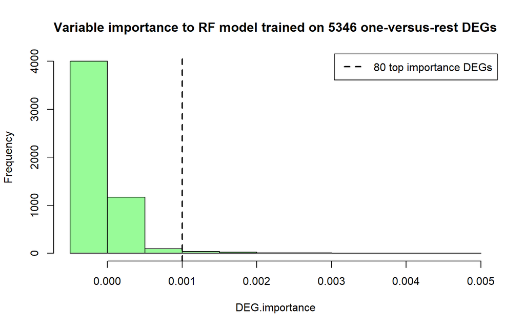

```r
## Try parameter optimization to see if performance for certain classes can be improved meaningfully

# Visualize the distribution of importance values from the RF model
DEG.importance <- RF.ovr.degs$importance[,"MeanDecreaseAccuracy"]
imp.cutoff <- 0.001
hist(DEG.importance, main=paste("Variable importance to RF model trained on",  length(useful.genes), "one-versus-rest DEGs"), col="palegreen")
abline(v=imp.cutoff, lty=2, lwd=2)
legend(x="topright", legend=paste(sum(DEG.importance>=imp.cutoff),"top importance DEGs"), lty=2, lwd=2)
```

```r
# Select only the top importance genes based on the histogram (to speed up optimization step next)
top.importance <- names(DEG.importance)[rank(-DEG.importance)<=80]
RF.top.imp <- randomForest(SampleType.factor ~., data=training.expr.useful[, top.importance, drop=FALSE], importance=TRUE, na.action="na.exclude")
get.perf.multi.class(RF.top.imp)
```

```
## $Confusion
##        Basal Her2 LumA LumB Normal
## Basal     17    0    0    0      0
## Her2       0    3    1    2      0
## LumA       0    0   40    2      0
## LumB       0    0    5   12      0
## Normal     0    1    2    0      0
##
## $Accuracy
## [1] 85
##
## $Performance
##        TPR TNR PPV FDR FPR
## Basal  100 100 100   0   0
## Her2    50  99  75  25   1
## LumA    95  81  83  17  19
## LumB    71  94  75  25   6
## Normal   0 100 NaN NaN   0
```

As seen in the histogram above, taking the 80 top importance DEGs seems like it covers the more extreme tail of the variable importance distribution from an RF model utilizing all unique one-versus-rest DEGs. Even though this step was being done to facilitate a faster optimization of `mtry` and `ntree` next, using fewer and more important genes actually resulted in improvements to the (overall) classification performance for all subtypes other than Basal (still perfect) and Normal (still minimal). That said, anything other than a robust Basal subtype classifier still seems iffy.

Below is a loop (like the one used earlier) to train an RF model with 80 top importance DEGs (one-versus-rest) using many combinations of `ntree` and `mtry` and recording the corresponding OOB error rates. The parameters that gave a minimal error rate are then retrieved from the optimization data frame and used to train a new RF model, whose performance is evaluated using `get.perf.multi.class()`.

```r
# Try optimizing ntrees and mtry with this new smaller number of variables (faster)
ntrees.vals <- c(25,50,100,200,400,800,1600)
mtrys <- seq(2,length(top.importance),2)
opt.results <- matrix(nrow=length(mtrys), ncol=length(ntrees.vals))
rownames(opt.results) <- mtrys
colnames(opt.results) <- ntrees.vals
for (i in 1:length(mtrys)) {
  for (j in 1:length(ntrees.vals)) {
    RF.tmp <- randomForest(SampleType.factor ~., data=training.expr.useful[, top.importance, drop=FALSE], mtry=mtrys[i], ntrees=ntrees.vals[j], importance=FALSE, na.action="na.exclude")
    opt.results[i,j] <- RF.tmp$err.rate[dim(RF.tmp$err.rate)[1],1]
  }
}

# See how a model using the best combination of ntrees and mtry performs
opt.summary <- as.data.frame(as.table(opt.results==min(opt.results)), stringsAsFactors=FALSE)
colnames(opt.summary) <- c("mtry", "ntree", "Min OOB error")
optimal.params <- opt.summary[opt.summary$"Min OOB error",]
optimal.params
```

```
##     mtry ntree Min OOB error
## 207   14   800          TRUE
```

```r
RF.opt <- randomForest(SampleType.factor ~., data=training.expr.useful[, top.importance, drop=FALSE], mtry=as.integer(optimal.params$mtry[1]), ntrees=as.integer(optimal.params$ntree[1]), importance=FALSE, na.action="na.exclude")
get.perf.multi.class(RF.opt)
```

```
## $Confusion
##        Basal Her2 LumA LumB Normal
## Basal     17    0    0    0      0
## Her2       0    4    1    1      0
## LumA       0    0   40    2      0
## LumB       0    0    4   13      0
## Normal     0    1    2    0      0
##
## $Accuracy
## [1] 87
##
## $Performance
##        TPR TNR PPV FDR FPR
## Basal  100 100 100   0   0
## Her2    67  99  80  20   1
## LumA    95  84  85  15  16
## LumB    76  96  81  19   4
## Normal   0 100 NaN NaN   0
```

As seen above, the optimal parameters found were `ntree=800` and `mtry=14` (a little greedier than the default of ~8 for 80 variables, but not too much so). The model trained using these parameters did exhibit an increase in overall performance compared to one using the defaults, but only a marginal increase (87% OOB accuracy above versus 85% earlier). This bump in performance was largely due to slight improvements with regards to the Her2 and LumB classes. That said, it now seems pretty clear that this model is really only reliable for identifying whether a tumor is Basal or not. It may be able to do a respectable job with the Luminal A subtype as well, but it does struggle with rejecting some non-LumA cases and that FDR of 15% seems a bit high. This was far from an exhaustive exploration of the possibilities, and perhaps decent separation of more subtypes is feasible with a much more elaborate variable selection strategy (and/or another model type). That said, I am inclined to trust the gist of the implications about class separability from PCA earlier and the RF model performance seen above.

## Testing

Given the fact that performance can be expected to drop below estimated levels when a classifier is exposed to data from a completely new source, I would rather use a model to achieve a simpler classification reliably than a complex classification unreliably. As such, when evaluating the final model’s performance on the test set below, I reframe the classification problem into a binary one considering only Basal versus non-Basal cases. The final model used is the one which relies on 80 top importance DEGs but uses the default RF parameters, as the optimization of the parameters conducted above did not effect performance with regards to the Basal subtype. Because the performance being evaluated is now for a binary classification problem, `assess.prediction()` is used below to calculate the performance metrics for this model on the test set.

```r
## Assess model performance on the test set
# from the OOB results it is clear the best this data allows (at least with RF, as used here)
# is to differentiate Basal subtypes from the others, so this is all that will be attempted

# Separate the truth values for the test set and reclassify into "Basal" and "Not Basal"
SampleType.char.test <- subtype[test.samples]
SampleType.char.test[!(SampleType.char.test %in% c("Basal"))] <- "Not Basal"
SampleType.factor.test <- as.factor(SampleType.char.test)

# Assess the model's ability to differentiate Basal subtype from the others
predictions.reclassed <- as.character(predict(RF.top.imp, as.data.frame(t(test.expr))))
predictions.reclassed[!(predictions.reclassed %in% c("Basal"))] <- "Not Basal"
Basal.vs.nonBasal <- assess.prediction(SampleType.factor.test, as.factor(predictions.reclassed), print.results = TRUE)
```

```
## Total cases that are not NA: 26
## Correct predictions (accuracy): 26(100%)
## TPR (sensitivity)=TP/P: 100%
## TNR (specificity)=TN/N: 100%
## PPV (precision)=TP/(TP+FP): 100%
## FDR (false discovery)=1-PPV: 0%
## FPR =FP/N=1-TNR: 0%
```

As expected, the RF model performs perfectly on the test data with regards to distinguishing Basal tumors from the other subtypes. While not the most ambitious classifier, this type of classification was supported by the exploration of the data conducted and does have value due to the high risk associated with the Basal subtype. Perhaps with a more complex/nuanced variable selection process, this data set could be used to develop a classifier that can perform reasonably well with regards to the Luminal A subtype as well, but that remains to be seen. I am even less certain about the possibility for building a reliable classifier for the other subtypes using this data set, particularly due to there being limited cases for 2 of those classes.

I was curious about whether any of the 80 genes utilized by the RF model above were among those in the PAM50 panel of genes, as those genes potentially represent one “solution” for more reliably differentiating between the 5 subtypes considered above. Thanks to a forum post on Biostars.org, I was able to find a Bioconductor package called `genefu` that gave me access to the symbols for these genes [11]. Below I map the Ensembl IDs of the 80 predictive variables from the RF model to gene symbols, using `org.Hs.eg.db`, and then find the overlap with the PAM50 symbols from `genefu`, along with those genes’ importance rank in that RF model:

```r
library("genefu")

# Get the list of PAM50 genes
# found out about "genefu" library here:
# https://www.biostars.org/p/77590/ [11]
data(pam50)
PAM50.genes <- rownames(pam50$centroids.ma)

# Map the Ensembl IDs for the genes used by the RF model to symbols
top.imp.symbols <- select(org.Hs.eg.db, keys = top.importance, columns = c("SYMBOL"), keytype = "ENSEMBL")

# Which symbols overlap between PAM50 and my model and what was their importance rank?
overlap <- top.imp.symbols$SYMBOL[top.imp.symbols$SYMBOL %in% PAM50.genes]
overlap.importance <- rank(-RF.top.imp$importance[,"MeanDecreaseAccuracy"])[select(org.Hs.eg.db, keys = overlap, columns = c("ENSEMBL"), keytype = "SYMBOL")$ENSEMBL]
names(overlap.importance) <- overlap
overlap.importance
```

```
##   CDC20   MYBL2   FOXC1    MELK   CEP55   FOXA1   BIRC5   PTTG1   CXXC5   UBE2T
##      19      57      71      43       9      24      62      46      22       3
##    MLPH   CCNE1    ESR1 SLC39A6
##       2      65       5      25
```

As seen above, 14 of the PAM50 genes were among those used by the final RF model that excelled at differentiating Basal subtype tumors from the rest in the test set. While many of these were not of particularly high relative importance to this model, some were among the most important, such as *MLPH*, *UBE2T*, *ESR1*, and *CEP55*. Not too surprisingly, these 4 genes have all been associated with breast cancer aggressiveness, prognosis, and/or pathogenic mechanisms in various ways, and some have even been explicitly associated with the Basal subtype [12-17].

# **References**

*In addition to all of the lecture notes:*

[1] Arshad, Z., & McDonald, J. F. (2022). A computational approach to generate highly conserved gene co-expression networks with RNA-seq data. In STAR Protocols (Vol. 3, Issue 2, p. 101432). Elsevier BV. https://doi.org/10.1016/j.xpro.2022.101432

[2] https://stackoverflow.com/questions/43636120/how-to-embed-plots-into-a-tab-in-rmarkdown-in-a-procedural-fashion

[3] Mathews, J. C., Nadeem, S., Levine, A. J., Pouryahya, M., Deasy, J. O., & Tannenbaum, A. (2019). Robust and interpretable PAM50 reclassification exhibits survival advantage for myoepithelial and immune phenotypes. In npj Breast Cancer (Vol. 5, Issue 1). Springer Science and Business Media LLC. https://doi.org/10.1038/s41523-019-0124-8

[4] Bertucci, F., Finetti, P., & Birnbaum, D. (2012). Basal Breast Cancer: A Complex and Deadly Molecular Subtype. In Current Molecular Medicine (Vol. 12, Issue 1, pp. 96–110). Bentham Science Publishers Ltd. https://doi.org/10.2174/156652412798376134

[5] James, G., Witten, D., Hastie, T., & Tibshirani, R. (2023). Chapter 8 - Tree-Based Methods. In An Introduction to Statistical Learning with Applications in R 2nd Edition (Springer). pp. 342-344.

[6] James, G., Witten, D., Hastie, T., & Tibshirani, R. (2023). Chapter 9 - Support Vector Machines. In An Introduction to Statistical Learning with Applications in R 2nd Edition (Springer). pp. 367-402.

[7] Faratian, D., Sims, A. H., Mullen, P., Kay, C., Um, I., Langdon, S. P., & Harrison, D. J. (2011). Sprouty 2 Is an Independent Prognostic Factor in Breast Cancer and May Be Useful in Stratifying Patients for Trastuzumab Therapy. In R. E. Means (Ed.), PLoS ONE (Vol. 6, Issue 8, p. e23772). Public Library of Science (PLoS). https://doi.org/10.1371/journal.pone.0023772

[8] Dai, H., Xu, W., Wang, L., Li, X., Sheng, X., Zhu, L., Li, Y., Dong, X., Zhou, W., Han, C., Mao, Y., & Yao, L. (2023). Loss of SPRY2 contributes to cancer-associated fibroblasts activation and promotes breast cancer development. In Breast Cancer Research (Vol. 25, Issue 1). Springer Science and Business Media LLC. https://doi.org/10.1186/s13058-023-01683-8

[9] Brogowska, K. K., Zajkowska, M., & Mroczko, B. (2023). Vascular Endothelial Growth Factor Ligands and Receptors in Breast Cancer. In Journal of Clinical Medicine (Vol. 12, Issue 6, p. 2412). MDPI AG. https://doi.org/10.3390/jcm12062412

[10] Lee, H., Park, B., Soon Kang, J., Cheon, Y., Lee, S., & Jae Maeng, P. (2020). MAM domain containing 2 is a potential breast cancer biomarker that exhibits tumour‐suppressive activity. In Cell Proliferation (Vol. 53, Issue 9). Wiley. https://doi.org/10.1111/cpr.12883

[11] https://www.biostars.org/p/77590/

[12] Thakkar, A., Raj, H., Ravishankar, Muthuvelan, B., Balakrishnan, A., & Padigaru, M. (2015). High Expression of Three-Gene Signature Improves Prediction of Relapse-Free Survival in Estrogen Receptor-Positive and Node-Positive Breast Tumors. In Biomarker Insights (Vol. 10, p. BMI.S30559). SAGE Publications. https://doi.org/10.4137/bmi.s30559

[13] Fountzilas, G., Wirtz, R. M., Skarlos, P., Dafni, U., Pectasides, D., Briasoulis, E., Bafaloukos, D., Xanthakis, I., Gehrmann, M., & Kalogeras, K. T. (2008). Molecular classification based on only four genes identifies basal-like subtypes in high-risk breast cancer patients. In Journal of Clinical Oncology (Vol. 26, Issue 15_suppl, pp. 11103–11103). American Society of Clinical Oncology (ASCO). https://doi.org/10.1200/jco.2008.26.15_suppl.11103

[14] Qin, T., Huang, G., Chi, L., Sui, S., Song, C., Li, N., Sun, S., Li, N., Zhang, M., Zhao, Z., Li, L., & Li, M. (2017). Exceptionally high UBE2C expression is a unique phenomenon in basal-like type breast cancer and is regulated by BRCA1. In Biomedicine & Pharmacotherapy (Vol. 95, pp. 649–655). Elsevier BV. https://doi.org/10.1016/j.biopha.2017.08.095

[15] Qiao, L., Dong, C., & Ma, B. (2021). UBE2T promotes proliferation, invasion and glycolysis of breast cancer cells by regualting the PI3K/AKT signaling pathway. In Journal of Receptors and Signal Transduction (Vol. 42, Issue 2, pp. 151–159). Informa UK Limited. https://doi.org/10.1080/10799893.2020.1870495

[16] Najim, O., Huizing, M., Papadimitriou, K., Trinh, X. B., Pauwels, P., Goethals, S., Zwaenepoel, K., Peterson, K., Weyler, J., Altintas, S., van Dam, P., & Tjalma, W. (2019). The prevalence of estrogen receptor-1 mutation in advanced breast cancer: The estrogen receptor one study (EROS1). In Cancer Treatment and Research Communications (Vol. 19, p. 100123). Elsevier BV. https://doi.org/10.1016/j.ctarc.2019.100123

[17] Kalimutho, M., Sinha, D., Jeffery, J., Nones, K., Srihari, S., Fernando, W. C., Duijf, P. H., Vennin, C., Raninga, P., Nanayakkara, D., Mittal, D., Saunus, J. M., Lakhani, S. R., López, J. A., Spring, K. J., Timpson, P., Gabrielli, B., Waddell, N., & Khanna, K. K. (2018). CEP55 is a determinant of cell fate during perturbed mitosis in breast cancer. In EMBO Molecular Medicine (Vol. 10, Issue 9). Springer Science and Business Media LLC. https://doi.org/10.15252/emmm.201708566